# BankMarketing caret v4 Balanced data

# options & settings

CSS for scrollable output & Header colors

chunk options

Turning scientific / Exponential numbers off

```r
options(scipen = 999)
```

## Source

https://www.machinelearningplus.com/machine-learning/caret-package/

https://youtu.be/mf1A_8K84rw

## Loading libs

```r
library(tidyverse)
library(ggthemes)
library(caret)
library(caretEnsemble)
library(ROSE)
```

```r
library(skimr)
library(naniar) # to plot missing values
library(scales)
library(glue)
library(patchwork)
library(GGally)
```

## Creating & setting custom theme

```r
theme_viny_bright <- function(){

  library(ggthemes)

  ggthemes::theme_fivethirtyeight() %+replace%

  theme(
    axis.title = element_text(),
    axis.text = element_text(size = 8),
    legend.text = element_text(size = 10),
    panel.background = element_rect(fill = "white"),
    plot.background = element_rect(fill = "white"),
    strip.background = element_blank(),
    legend.background = element_rect(fill = NA),
    legend.key = element_rect(fill = NA),
    plot.title = element_text(hjust = 0.5,
                              size = 19,
                              face = "bold"),
    plot.subtitle = element_text(hjust = 0.5)
      )

  }

theme_set(theme_viny_bright())
```

# Loading data

```r
data <- read.csv("bank-additional.csv", header = TRUE, sep = ";")

head(data)
```

|  | age | job | marital | education | default | housing | loan | contact | month | day_of_week | duration | campaign | pdays | previous | poutcome | emp.var.rate | cons.price.idx | cons.conf.idx | euribor3m | nr.employed | y |
| --- | --- | --- | --- | --- | --- | --- | --- | --- | --- | --- | --- | --- | --- | --- | --- | --- | --- | --- | --- | --- | --- |
| 1 | 30 | blue-collar | married | basic.9y | no | yes | no | cellular | may | fri | 487 | 2 | 999 | 0 | nonexistent | -1.8 | 92.893 | -46.2 | 1.313 | 5099.1 | no |
| 2 | 39 | services | single | high.school | no | no | no | telephone | may | fri | 346 | 4 | 999 | 0 | nonexistent | 1.1 | 93.994 | -36.4 | 4.855 | 5191.0 | no |
| 3 | 25 | services | married | high.school | no | yes | no | telephone | jun | wed | 227 | 1 | 999 | 0 | nonexistent | 1.4 | 94.465 | -41.8 | 4.962 | 5228.1 | no |
| 4 | 38 | services | married | basic.9y | no | unknown | unknown | telephone | jun | fri | 17 | 3 | 999 | 0 | nonexistent | 1.4 | 94.465 | -41.8 | 4.959 | 5228.1 | no |
| 5 | 47 | admin. | married | university.degree | no | yes | no | cellular | nov | mon | 58 | 1 | 999 | 0 | nonexistent | -0.1 | 93.200 | -42.0 | 4.191 | 5195.8 | no |
| 6 | 32 | services | single | university.degree | no | no | no | cellular | sep | thu | 128 | 3 | 999 | 2 | failure | -1.1 | 94.199 | -37.5 | 0.884 | 4963.6 | no |

# Exploring data

```r
str(data)
```

```
'data.frame':   4119 obs. of  21 variables:
 $ age           : int  30 39 25 38 47 32 32 41 31 35 ...
 $ job           : chr  "blue-collar" "services" "services" "services" ...
 $ marital       : chr  "married" "single" "married" "married" ...
 $ education     : chr  "basic.9y" "high.school" "high.school" "basic.9y" ...
 $ default       : chr  "no" "no" "no" "no" ...
 $ housing       : chr  "yes" "no" "yes" "unknown" ...
 $ loan          : chr  "no" "no" "no" "unknown" ...
 $ contact       : chr  "cellular" "telephone" "telephone" "telephone" ...
 $ month         : chr  "may" "may" "jun" "jun" ...
 $ day_of_week   : chr  "fri" "fri" "wed" "fri" ...
 $ duration      : int  487 346 227 17 58 128 290 44 68 170 ...
 $ campaign      : int  2 4 1 3 1 3 4 2 1 1 ...
 $ pdays         : int  999 999 999 999 999 999 999 999 999 999 ...
 $ previous      : int  0 0 0 0 0 2 0 0 1 0 ...
 $ poutcome      : chr  "nonexistent" "nonexistent" "nonexistent" "nonexistent" ...
 $ emp.var.rate  : num  -1.8 1.1 1.4 1.4 -0.1 -1.1 -1.1 -0.1 -0.1 1.1 ...
 $ cons.price.idx: num  92.9 94 94.5 94.5 93.2 ...
 $ cons.conf.idx : num  -46.2 -36.4 -41.8 -41.8 -42 -37.5 -37.5 -42 -42 -36.4 ...
 $ euribor3m     : num  1.31 4.86 4.96 4.96 4.19 ...
 $ nr.employed   : num  5099 5191 5228 5228 5196 ...
 $ y             : chr  "no" "no" "no" "no" ...
```

also setting months levels correctly so that it can be sorted by calender order of month

```r
data <- data %>%
    mutate(across(is.character, factor),
           month = str_to_title(month), # this will correct text style to month.abbr
           month = factor(month, levels = month.abb), # this will sort the months
           month = factor(month))  # this will drop two unused levels - Jan, Feb

str(data)
```

```
'data.frame':   4119 obs. of  21 variables:
 $ age           : int  30 39 25 38 47 32 32 41 31 35 ...
 $ job           : Factor w/ 12 levels "admin.","blue-collar",..: 2 8 8 8 1 8 1 3 8 2 ...
 $ marital       : Factor w/ 4 levels "divorced","married",..: 2 3 2 2 2 3 3 2 1 2 ...
 $ education     : Factor w/ 8 levels "basic.4y","basic.6y",..: 3 4 4 3 7 7 7 7 6 3 ...
 $ default       : Factor w/ 3 levels "no","unknown",..: 1 1 1 1 1 1 1 2 1 2 ...
 $ housing       : Factor w/ 3 levels "no","unknown",..: 3 1 3 2 3 1 3 3 1 1 ...
 $ loan          : Factor w/ 3 levels "no","unknown",..: 1 1 1 2 1 1 1 1 1 1 ...
 $ contact       : Factor w/ 2 levels "cellular","telephone": 1 2 2 2 1 1 1 1 1 2 ...
 $ month         : Factor w/ 10 levels "Mar","Apr","May",..: 3 3 4 4 9 7 7 9 9 3 ...
 $ day_of_week   : Factor w/ 5 levels "fri","mon","thu",..: 1 1 5 1 2 3 2 2 4 3 ...
 $ duration      : int  487 346 227 17 58 128 290 44 68 170 ...
 $ campaign      : int  2 4 1 3 1 3 4 2 1 1 ...
 $ pdays         : int  999 999 999 999 999 999 999 999 999 999 ...
 $ previous      : int  0 0 0 0 0 2 0 0 1 0 ...
 $ poutcome      : Factor w/ 3 levels "failure","nonexistent",..: 2 2 2 2 2 1 2 2 1 2 ...
 $ emp.var.rate  : num  -1.8 1.1 1.4 1.4 -0.1 -1.1 -1.1 -0.1 -0.1 1.1 ...
 $ cons.price.idx: num  92.9 94 94.5 94.5 93.2 ...
 $ cons.conf.idx : num  -46.2 -36.4 -41.8 -41.8 -42 -37.5 -37.5 -42 -42 -36.4 ...
 $ euribor3m     : num  1.31 4.86 4.96 4.96 4.19 ...
 $ nr.employed   : num  5099 5191 5228 5228 5196 ...
 $ y             : Factor w/ 2 levels "no","yes": 1 1 1 1 1 1 1 1 1 1 ...
```

find missing values

```r
sapply(data, function(x) sum(is.na(x)))
```

```
           age            job        marital      education        default        housing
             0              0              0              0              0              0
          loan        contact          month    day_of_week       duration       campaign
             0              0              0              0              0              0
         pdays       previous       poutcome   emp.var.rate cons.price.idx  cons.conf.idx
             0              0              0              0              0              0
     euribor3m    nr.employed              y
             0              0              0
```

```r
summary(data)
```

```
      age                 job           marital                   education       default
 Min.   :18.00   admin.     :1012   divorced: 446   university.degree  :1264   no     :3315
 1st Qu.:32.00   blue-collar: 884   married :2509   high.school        : 921   unknown: 803
 Median :38.00   technician : 691   single  :1153   basic.9y           : 574   yes    :   1
 Mean   :40.11   services   : 393   unknown :  11   professional.course: 535
 3rd Qu.:47.00   management : 324                   basic.4y           : 429
 Max.   :88.00   retired    : 166                   basic.6y           : 228
                 (Other)    : 649                   (Other)            : 168
    housing          loan           contact         month      day_of_week    duration
 no     :1839   no     :3349   cellular :2652   May    :1378   fri:768     Min.   :   0.0
 unknown: 105   unknown: 105   telephone:1467   Jul    : 711   mon:855     1st Qu.: 103.0
 yes    :2175   yes    : 665                    Aug    : 636   thu:860     Median : 181.0
                                                Jun    : 530   tue:841     Mean   : 256.8
                                                Nov    : 446   wed:795     3rd Qu.: 317.0
                                                Apr    : 215               Max.   :3643.0
                                                (Other): 203
    campaign          pdays          previous             poutcome     emp.var.rate
 Min.   : 1.000   Min.   :  0.0   Min.   :0.0000   failure    : 454   Min.   :-3.40000
 1st Qu.: 1.000   1st Qu.:999.0   1st Qu.:0.0000   nonexistent:3523   1st Qu.:-1.80000
 Median : 2.000   Median :999.0   Median :0.0000   success    : 142   Median : 1.10000
 Mean   : 2.537   Mean   :960.4   Mean   :0.1903                      Mean   : 0.08497
 3rd Qu.: 3.000   3rd Qu.:999.0   3rd Qu.:0.0000                      3rd Qu.: 1.40000
 Max.   :35.000   Max.   :999.0   Max.   :6.0000                      Max.   : 1.40000

 cons.price.idx  cons.conf.idx     euribor3m      nr.employed     y
 Min.   :92.20   Min.   :-50.8   Min.   :0.635   Min.   :4964   no :3668
 1st Qu.:93.08   1st Qu.:-42.7   1st Qu.:1.334   1st Qu.:5099   yes: 451
 Median :93.75   Median :-41.8   Median :4.857   Median :5191
 Mean   :93.58   Mean   :-40.5   Mean   :3.621   Mean   :5166
 3rd Qu.:93.99   3rd Qu.:-36.4   3rd Qu.:4.961   3rd Qu.:5228
 Max.   :94.77   Max.   :-26.9   Max.   :5.045   Max.   :5228
```

```r
data %>%
  select(where(is.factor)) %>% head()
```

|  | job | marital | education | default | housing | loan | contact | month | day_of_week | poutcome | y |
| --- | --- | --- | --- | --- | --- | --- | --- | --- | --- | --- | --- |
| 1 | blue-collar | married | basic.9y | no | yes | no | cellular | May | fri | nonexistent | no |
| 2 | services | single | high.school | no | no | no | telephone | May | fri | nonexistent | no |
| 3 | services | married | high.school | no | yes | no | telephone | Jun | wed | nonexistent | no |
| 4 | services | married | basic.9y | no | unknown | unknown | telephone | Jun | fri | nonexistent | no |
| 5 | admin. | married | university.degree | no | yes | no | cellular | Nov | mon | nonexistent | no |
| 6 | services | single | university.degree | no | no | no | cellular | Sep | thu | failure | no |

```r
table(data$job)
```

```
       admin.   blue-collar  entrepreneur     housemaid    management       retired self-employed
         1012           884           148           110           324           166           159
     services       student    technician    unemployed       unknown
          393            82           691           111            39
```

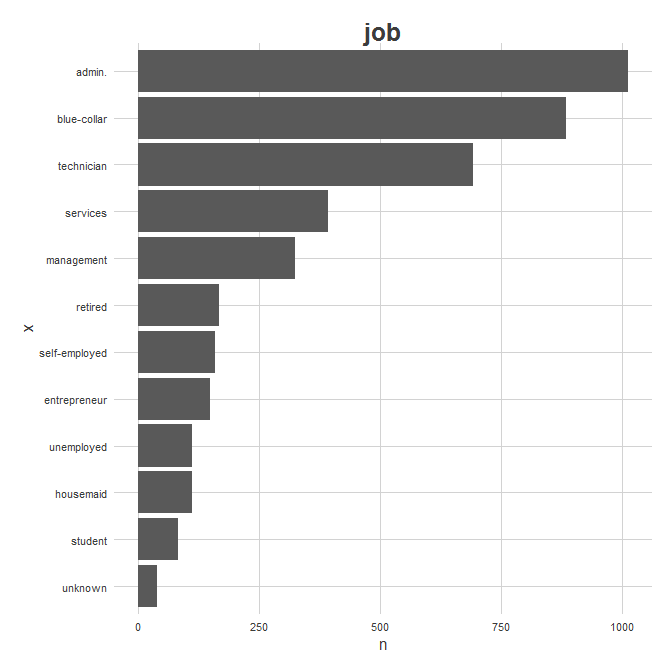

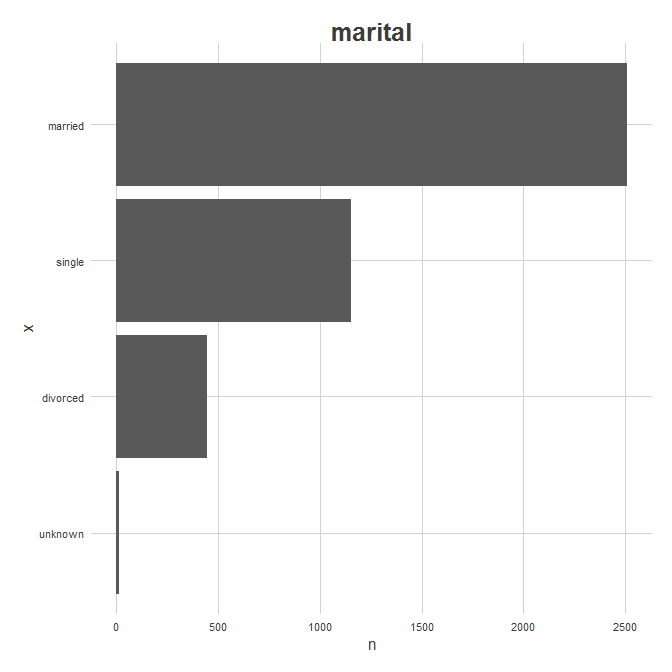

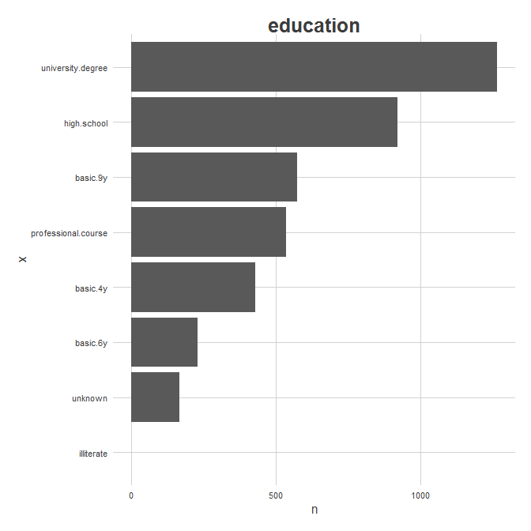

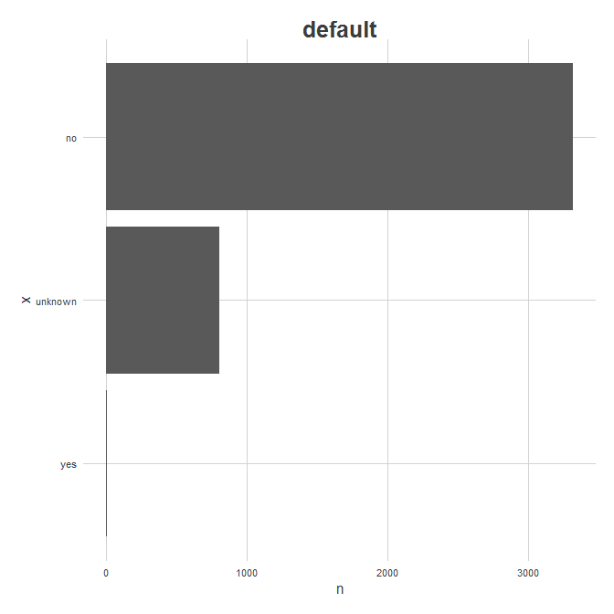

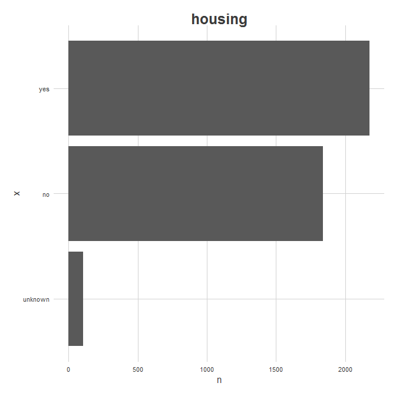

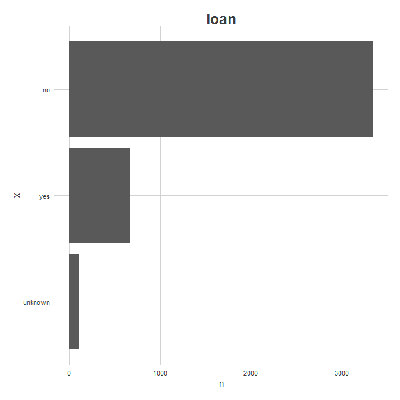

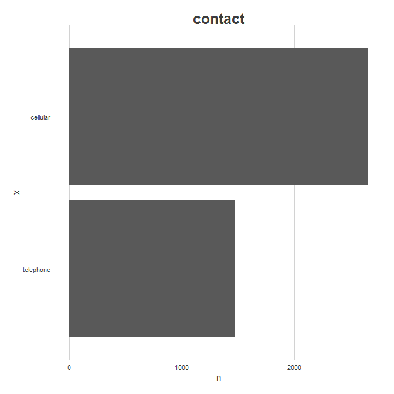

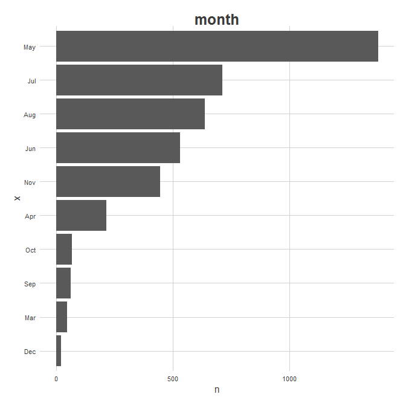

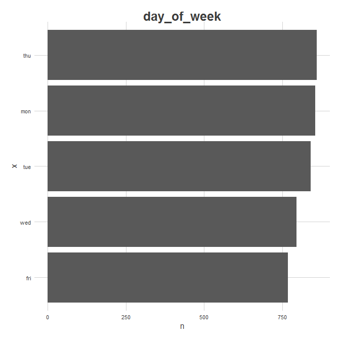

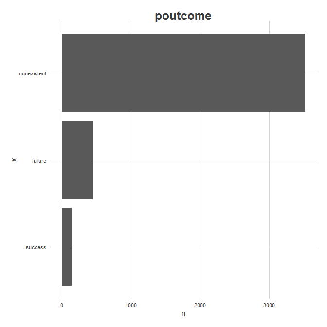

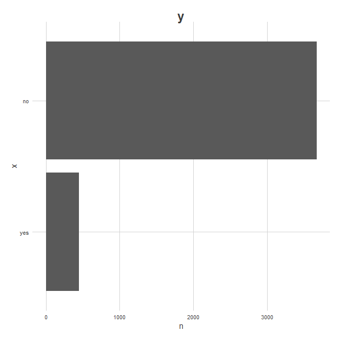

```r
data %>%
  select(where(is.factor)) %>%

  imap(function(feature_value, feature_name) {

    count(data.frame(x = feature_value), x) %>%
    mutate(x = fct_reorder(x, n)) %>%

      ggplot(aes(x = x, y = n)) +
      geom_col() +
      coord_flip() +
      labs(title = feature_name)
  })
```

```r
skim(data)
```

```
-- Data Summary ------------------------
                           Values
Name                       data
Number of rows             4119
Number of columns          21
_______________________
Column type frequency:
  factor                   11
  numeric                  10
________________________
Group variables            None

-- Variable type: factor ------------------------------------------------------------------------------
# A tibble: 11 x 6
   skim_variable n_missing complete_rate ordered n_unique top_counts
 * <chr>             <int>         <dbl> <lgl>      <int> <chr>
 1 job                   0             1 FALSE         12 adm: 1012, blu: 884, tec: 691, ser: 393
 2 marital               0             1 FALSE          4 mar: 2509, sin: 1153, div: 446, unk: 11
 3 education             0             1 FALSE          8 uni: 1264, hig: 921, bas: 574, pro: 535
 4 default               0             1 FALSE          3 no: 3315, unk: 803, yes: 1
 5 housing               0             1 FALSE          3 yes: 2175, no: 1839, unk: 105
 6 loan                  0             1 FALSE          3 no: 3349, yes: 665, unk: 105
 7 contact               0             1 FALSE          2 cel: 2652, tel: 1467
 8 month                 0             1 FALSE         10 May: 1378, Jul: 711, Aug: 636, Jun: 530
 9 day_of_week           0             1 FALSE          5 thu: 860, mon: 855, tue: 841, wed: 795
10 poutcome              0             1 FALSE          3 non: 3523, fai: 454, suc: 142
11 y                     0             1 FALSE          2 no: 3668, yes: 451

-- Variable type: numeric -----------------------------------------------------------------------------
# A tibble: 10 x 11
   skim_variable  n_missing complete_rate      mean      sd       p0     p25     p50     p75    p100
 * <chr>              <int>         <dbl>     <dbl>   <dbl>    <dbl>   <dbl>   <dbl>   <dbl>   <dbl>
 1 age                    0             1   40.1     10.3     18       32      38      47      88
 2 duration               0             1  257.     255.       0      103     181     317    3643
 3 campaign               0             1    2.54     2.57     1        1       2       3      35
 4 pdays                  0             1  960.     192.       0      999     999     999     999
 5 previous               0             1    0.190    0.542    0        0       0       0       6
 6 emp.var.rate           0             1    0.0850   1.56    -3.4     -1.8     1.1     1.4     1.4
 7 cons.price.idx         0             1   93.6      0.579   92.2     93.1    93.7    94.0    94.8
 8 cons.conf.idx          0             1  -40.5      4.59   -50.8    -42.7   -41.8   -36.4   -26.9
 9 euribor3m              0             1    3.62     1.73     0.635    1.33    4.86    4.96    5.04
10 nr.employed            0             1 5166.      73.7   4964.    5099.   5191    5228.   5228.
   hist
 * <chr>
 1 ▅▇▅▁▁
 2 ▇▁▁▁▁
 3 ▇▁▁▁▁
 4 ▁▁▁▁▇
 5 ▇▁▁▁▁
 6 ▁▃▁▁▇
 7 ▁▆▃▇▂
 8 ▅▇▁▇▁
 9 ▅▁▁▁▇
10 ▁▁▃▁▇
```

# splitting data - Train Test

```r
set.seed(123)

data_split_index <- createDataPartition(data$y, p = 0.7, list = FALSE)

train <- data[data_split_index,]
test <- data[-data_split_index,]

dim(train)
```

```
[1] 2884   21
```

```r
dim(test)
```

```
[1] 1235   21
```

```r
y_train = subset(train, select = y)
X_train = subset(train, select = -y)
```

```r
y_test = subset(test, select = y)
X_test = subset(test, select = -y)
```

## Exploring Train data

```r
summary(train)
```

```
      age                 job          marital                   education      default
 Min.   :19.00   admin.     :713   divorced: 301   university.degree  :872   no     :2324
 1st Qu.:32.00   blue-collar:609   married :1729   high.school        :656   unknown: 560
 Median :38.00   technician :490   single  : 848   basic.9y           :396   yes    :   0
 Mean   :40.05   services   :287   unknown :   6   professional.course:380
 3rd Qu.:47.00   management :228                   basic.4y           :299
 Max.   :88.00   retired    :110                   basic.6y           :159
                 (Other)    :447                   (Other)            :122
    housing          loan           contact         month     day_of_week    duration
 no     :1301   no     :2358   cellular :1867   May    :967   fri:517     Min.   :   0.0
 unknown:  69   unknown:  69   telephone:1017   Jul    :508   mon:619     1st Qu.: 102.0
 yes    :1514   yes    : 457                    Aug    :452   thu:598     Median : 180.0
                                                Jun    :359   tue:583     Mean   : 256.3
                                                Nov    :311   wed:567     3rd Qu.: 321.2
                                                Apr    :147               Max.   :1980.0
                                                (Other):140
    campaign          pdays          previous             poutcome     emp.var.rate
 Min.   : 1.000   Min.   :  0.0   Min.   :0.0000   failure    : 315   Min.   :-3.40000
 1st Qu.: 1.000   1st Qu.:999.0   1st Qu.:0.0000   nonexistent:2470   1st Qu.:-1.80000
 Median : 2.000   Median :999.0   Median :0.0000   success    :  99   Median : 1.10000
 Mean   : 2.551   Mean   :960.8   Mean   :0.1862                      Mean   : 0.08925
 3rd Qu.: 3.000   3rd Qu.:999.0   3rd Qu.:0.0000                      3rd Qu.: 1.40000
 Max.   :35.000   Max.   :999.0   Max.   :6.0000                      Max.   : 1.40000

 cons.price.idx  cons.conf.idx      euribor3m      nr.employed     y
 Min.   :92.20   Min.   :-50.80   Min.   :0.635   Min.   :4964   no :2568
 1st Qu.:93.08   1st Qu.:-42.70   1st Qu.:1.334   1st Qu.:5099   yes: 316
 Median :93.75   Median :-41.80   Median :4.857   Median :5191
 Mean   :93.57   Mean   :-40.44   Mean   :3.628   Mean   :5167
 3rd Qu.:93.99   3rd Qu.:-36.40   3rd Qu.:4.961   3rd Qu.:5228
 Max.   :94.77   Max.   :-26.90   Max.   :4.970   Max.   :5228
```

### featureplot

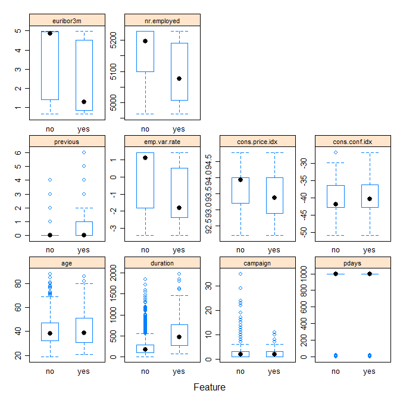

```r
train %>%
  select_if(is.numeric) %>%
  featurePlot(x = .,
              y = train$y,
              plot = "box",
              strip=strip.custom(par.strip.text=list(cex=.7)),
              scales = list(x = list(relation="free"),
                            y = list(relation="free"))
              )
```

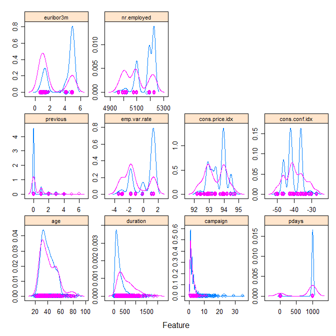

```r
train %>%
  select_if(is.numeric) %>%
  featurePlot(x = .,
              y = train$y,
              plot = "density",
              strip=strip.custom(par.strip.text=list(cex=.7)),
              scales = list(x = list(relation="free"),
                            y = list(relation="free"))
              )
```

# Data Pre Processing

## impute missing values

```r
# pp_impute <- preProcess(train, method = "knnIknnImpute")
#
library(RANN)
#
# train <- predict(pp_impute, newdata = train)
# anyNA(train)
```

## Outlier treatment

from: E:\3. RPractice\1.DataPreProcessing_HousingPrices.Rmd

```r
# outlier_cap <- function(x, na.rm = TRUE){
#
#   upper_cap = 3 * quantile(x, 0.99, na.rm = T)
#   lower_cap = 0.3 * quantile(x, 0.01, na.rm = T)
#
#   x[x > upper_cap] = upper_cap
#   x[x < lower_cap] = lower_cap
#
#   x <- x
# }
```

from: https://stackoverflow.com/questions/13339685/how-to-replace-outliers-with-the-5th-and-95th-percentile-values-in-r

```r
# outlier_cap <- function(x) {
#   quantiles <- quantile(x, c(0.05, 0.95) )
#
#   x[x < quantiles[1]] <- quantiles[1]
#   x[x > quantiles[2]] <- quantiles[2]
#
#   x
# }
```

```r
outlier_cap <- function(x, na.rm = TRUE){

  upper_cap = quantile(x, 0.99, na.rm = T)
  lower_cap = quantile(x, 0.01, na.rm = T)

  x[x > upper_cap] = upper_cap
  x[x < lower_cap] = lower_cap

  x <- x
}
```

```r
train <- train %>% mutate_if(is.numeric, outlier_cap)

# confirming if outlier capping worked or not
train %>% select_if(is.numeric) %>% summary(.)
```

```
      age           duration         campaign          pdays          previous       emp.var.rate
 Min.   :23.00   Min.   :  10.0   Min.   : 1.000   Min.   :  3.0   Min.   :0.0000   Min.   :-3.40000
 1st Qu.:32.00   1st Qu.: 102.0   1st Qu.: 1.000   1st Qu.:999.0   1st Qu.:0.0000   1st Qu.:-1.80000
 Median :38.00   Median : 180.0   Median : 2.000   Median :999.0   Median :0.0000   Median : 1.10000
 Mean   :39.97   Mean   : 253.6   Mean   : 2.506   Mean   :960.8   Mean   :0.1723   Mean   : 0.08925
 3rd Qu.:47.00   3rd Qu.: 321.2   3rd Qu.: 3.000   3rd Qu.:999.0   3rd Qu.:0.0000   3rd Qu.: 1.40000
 Max.   :67.17   Max.   :1196.4   Max.   :14.000   Max.   :999.0   Max.   :2.0000   Max.   : 1.40000
 cons.price.idx  cons.conf.idx      euribor3m      nr.employed
 Min.   :92.20   Min.   :-50.00   Min.   :0.659   Min.   :4964
 1st Qu.:93.08   1st Qu.:-42.70   1st Qu.:1.334   1st Qu.:5099
 Median :93.75   Median :-41.80   Median :4.857   Median :5191
 Mean   :93.57   Mean   :-40.46   Mean   :3.628   Mean   :5167
 3rd Qu.:93.99   3rd Qu.:-36.40   3rd Qu.:4.961   3rd Qu.:5228
 Max.   :94.47   Max.   :-29.31   Max.   :4.968   Max.   :5228
```

```r
levels(train$job)
```

```
 [1] "admin."        "blue-collar"   "entrepreneur"  "housemaid"     "management"    "retired"
 [7] "self-employed" "services"      "student"       "technician"    "unemployed"    "unknown"
```

```r
table(train$y)
```

```
  no  yes
2568  316
```

# Balancing data

## both sampling

```r
train_both_sample <- ROSE::ovun.sample(y ~ ., data = train, method = "both", p=0.5, N = 2884, seed = 1)$data
table(train_both_sample$y)
```

```
  no  yes
1503 1381
```

## One Hot Encoding

```r
Y = subset(data, select = y)
X = subset(data, select = -y)
```

```r
dim(X)
```

```
[1] 4119   20
```

```r
dim(Y)
```

```
[1] 4119    1
```

```r
typeof(Y)
```

```
[1] "list"
```

```r
class(Y)
```

```
[1] "data.frame"
```

```r
class(data$age)
```

```
[1] "integer"
```

```r
class(as.factor(Y))
```

```
[1] "factor"
```

```r
Y_train = subset(train_both_sample, select = y)
X_train = subset(train_both_sample, select = -y)
```

```r
Y_test = subset(test, select = y)
X_test = subset(test, select = -y)
```

```r
pp_dummy <- dummyVars(y ~ ., data = train_both_sample)

train_both_sample <- predict(pp_dummy, newdata = train_both_sample)
train_both_sample <- data.frame(train_both_sample)

test <- predict(pp_dummy, newdata = test)
test <- data.frame(test)

str(train_both_sample)
```

```
'data.frame':   2884 obs. of  63 variables:
 $ age                          : num  31 45 33 47 30 43 23 42 43 37 ...
 $ job.admin.                   : num  0 0 0 0 0 0 0 0 0 1 ...
 $ job.blue.collar              : num  1 0 0 1 0 1 0 0 1 0 ...
 $ job.entrepreneur             : num  0 0 0 0 0 0 1 0 0 0 ...
 $ job.housemaid                : num  0 0 0 0 0 0 0 0 0 0 ...
 $ job.management               : num  0 0 0 0 0 0 0 1 0 0 ...
 $ job.retired                  : num  0 0 0 0 0 0 0 0 0 0 ...
 $ job.self.employed            : num  0 0 0 0 0 0 0 0 0 0 ...
 $ job.services                 : num  0 1 0 0 0 0 0 0 0 0 ...
 $ job.student                  : num  0 0 0 0 0 0 0 0 0 0 ...
 $ job.technician               : num  0 0 1 0 1 0 0 0 0 0 ...
 $ job.unemployed               : num  0 0 0 0 0 0 0 0 0 0 ...
 $ job.unknown                  : num  0 0 0 0 0 0 0 0 0 0 ...
 $ marital.divorced             : num  0 0 0 0 0 0 0 0 0 0 ...
```

[output cut: 49 more lines]

# Variables Selection

## Near Zero Variance

from: https://topepo.github.io/caret/pre-processing.html

```r
nzv <- nearZeroVar(train_both_sample, saveMetrics = TRUE)
nzv
```

|  | freqRatio | percentUnique | zeroVar | nzv |
| --- | --- | --- | --- | --- |
| age | 1.047619 | 1.56033287 | FALSE | FALSE |
| job.admin. | 2.794737 | 0.06934813 | FALSE | FALSE |
| job.blue.collar | 4.791165 | 0.06934813 | FALSE | FALSE |
| job.entrepreneur | 28.428571 | 0.06934813 | FALSE | TRUE |
| job.housemaid | 47.881356 | 0.06934813 | FALSE | TRUE |
| job.management | 13.492462 | 0.06934813 | FALSE | FALSE |
| job.retired | 18.099338 | 0.06934813 | FALSE | FALSE |
| job.self.employed | 32.149425 | 0.06934813 | FALSE | TRUE |
| job.services | 9.564103 | 0.06934813 | FALSE | FALSE |
| job.student | 28.131313 | 0.06934813 | FALSE | TRUE |

[output cut: 53 more lines]

```r
nzv_list <- nearZeroVar(train_both_sample) %>%
            as.vector()

nzv_list
```

```
 [1]  4  5  8 10 12 13 17 19 22 25 28 30 33 37 43 44 46
```

```r
selected_vars <- train_both_sample[, -nzv_list ]

str(selected_vars)
```

```
'data.frame':   2884 obs. of  46 variables:
 $ age                          : num  31 45 33 47 30 43 23 42 43 37 ...
 $ job.admin.                   : num  0 0 0 0 0 0 0 0 0 1 ...
 $ job.blue.collar              : num  1 0 0 1 0 1 0 0 1 0 ...
 $ job.management               : num  0 0 0 0 0 0 0 1 0 0 ...
 $ job.retired                  : num  0 0 0 0 0 0 0 0 0 0 ...
 $ job.services                 : num  0 1 0 0 0 0 0 0 0 0 ...
 $ job.technician               : num  0 0 1 0 1 0 0 0 0 0 ...
 $ marital.divorced             : num  0 0 0 0 0 0 0 0 0 0 ...
 $ marital.married              : num  1 1 1 1 0 1 1 1 1 1 ...
 $ marital.single               : num  0 0 0 0 1 0 0 0 0 0 ...
 $ education.basic.4y           : num  0 0 0 0 0 0 0 0 0 0 ...
 $ education.basic.9y           : num  1 0 0 0 0 0 0 0 1 0 ...
 $ education.high.school        : num  0 1 0 0 0 1 0 0 0 1 ...
 $ education.professional.course: num  0 0 1 0 1 0 0 0 0 0 ...
```

[output cut: 32 more lines]

append y to train

```r
selected_vars$y <- Y_train # as.factor(Y)

str(selected_vars)
```

```
'data.frame':   2884 obs. of  47 variables:
 $ age                          : num  31 45 33 47 30 43 23 42 43 37 ...
 $ job.admin.                   : num  0 0 0 0 0 0 0 0 0 1 ...
 $ job.blue.collar              : num  1 0 0 1 0 1 0 0 1 0 ...
 $ job.management               : num  0 0 0 0 0 0 0 1 0 0 ...
 $ job.retired                  : num  0 0 0 0 0 0 0 0 0 0 ...
 $ job.services                 : num  0 1 0 0 0 0 0 0 0 0 ...
 $ job.technician               : num  0 0 1 0 1 0 0 0 0 0 ...
 $ marital.divorced             : num  0 0 0 0 0 0 0 0 0 0 ...
 $ marital.married              : num  1 1 1 1 0 1 1 1 1 1 ...
 $ marital.single               : num  0 0 0 0 1 0 0 0 0 0 ...
 $ education.basic.4y           : num  0 0 0 0 0 0 0 0 0 0 ...
 $ education.basic.9y           : num  1 0 0 0 0 0 0 0 1 0 ...
 $ education.high.school        : num  0 1 0 0 0 1 0 0 0 1 ...
 $ education.professional.course: num  0 0 1 0 1 0 0 0 0 0 ...
```

[output cut: 34 more lines]

```r
# data <- data %>% mutate(y = as.factor(y))

# str(data)
```

Since appending Y as factor is causing NA in the oclumn so quiting this step of adding Y as factor

```r
anyNA(selected_vars)
```

```
[1] FALSE
```

## RFE

https://www.machinelearningplus.com/machine-learning/caret-package/

http://topepo.github.io/caret/recursive-feature-elimination.html#rfe

this also took around 32 mins

```r
control <- rfeControl(functions = rfFuncs, method = "cv", verbose = FALSE)

system.time(
  RFE_both_smpl_res <- rfe(x = subset(selected_vars, select = -y),    #  selected_vars[, 1:44]
                 y = pull(selected_vars$y),
                 sizes = c(7, 15, 20),
                 rfeControl = control
                 )
)
```

```r
# saveRDS(RFE_both_smpl_res, "RFE_both_smpl_res.rds")

RFE_both_smpl_res <- readRDS("RFE_both_smpl_res.rds")
```

```r
RFE_both_smpl_res
```

```
Recursive feature selection

Outer resampling method: Cross-Validated (10 fold)

Resampling performance over subset size:
```

|  | Variables | Accuracy | Kappa | AccuracySD | KappaSD | Selected |
| --- | --- | --- | --- | --- | --- | --- |
| 1 | 7 | 0.9615 | 0.9231 | 0.011863 | 0.02363 |  |
| 2 | 15 | 0.9653 | 0.9307 | 0.009954 | 0.01980 |  |
| 3 | 20 | 0.9684 | 0.9369 | 0.010651 | 0.02122 |  |
| 4 | 46 | 0.9736 | 0.9473 | 0.010242 | 0.02043 | * |

```
The top 5 variables (out of 46):
   duration, age, campaign, euribor3m, cons.conf.idx
```

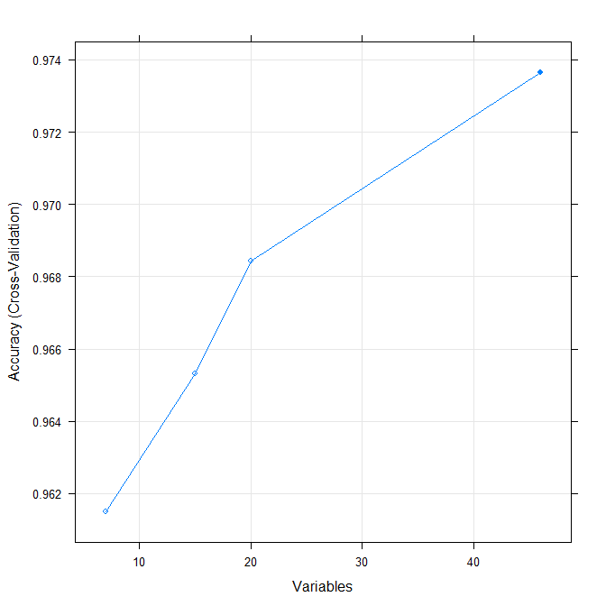

```r
plot(RFE_both_smpl_res, type=c("g","o"))
```

```r
RFE_both_smpl_res$optVariables
```

```
 [1] "duration"                      "age"                           "campaign"
 [4] "euribor3m"                     "cons.conf.idx"                 "cons.price.idx"
 [7] "nr.employed"                   "housing.no"                    "housing.yes"
[10] "day_of_week.thu"               "emp.var.rate"                  "marital.single"
[13] "education.high.school"         "day_of_week.mon"               "job.technician"
[16] "marital.married"               "day_of_week.tue"               "job.admin."
[19] "education.university.degree"   "day_of_week.wed"               "education.professional.course"
[22] "marital.divorced"              "loan.no"                       "day_of_week.fri"
[25] "job.retired"                   "pdays"                         "loan.yes"
[28] "poutcome.failure"              "month.May"                     "education.basic.9y"
[31] "job.services"                  "contact.telephone"             "contact.cellular"
[34] "job.blue.collar"               "poutcome.success"              "previous"
[37] "month.Apr"                     "job.management"                "education.basic.4y"
[40] "poutcome.nonexistent"          "month.Jun"                     "month.Nov"
[43] "default.unknown"               "default.no"                    "month.Aug"
[46] "month.Jul"
```

```r
predictors(RFE_both_smpl_res)
```

```
 [1] "duration"                      "age"                           "campaign"
 [4] "euribor3m"                     "cons.conf.idx"                 "cons.price.idx"
 [7] "nr.employed"                   "housing.no"                    "housing.yes"
[10] "day_of_week.thu"               "emp.var.rate"                  "marital.single"
[13] "education.high.school"         "day_of_week.mon"               "job.technician"
[16] "marital.married"               "day_of_week.tue"               "job.admin."
[19] "education.university.degree"   "day_of_week.wed"               "education.professional.course"
[22] "marital.divorced"              "loan.no"                       "day_of_week.fri"
[25] "job.retired"                   "pdays"                         "loan.yes"
[28] "poutcome.failure"              "month.May"                     "education.basic.9y"
[31] "job.services"                  "contact.telephone"             "contact.cellular"
[34] "job.blue.collar"               "poutcome.success"              "previous"
[37] "month.Apr"                     "job.management"                "education.basic.4y"
[40] "poutcome.nonexistent"          "month.Jun"                     "month.Nov"
[43] "default.unknown"               "default.no"                    "month.Aug"
[46] "month.Jul"
```

```r
RFE_both_smpl_res$optVariables[1:15]
```

```
 [1] "duration"              "age"                   "campaign"              "euribor3m"
 [5] "cons.conf.idx"         "cons.price.idx"        "nr.employed"           "housing.no"
 [9] "housing.yes"           "day_of_week.thu"       "emp.var.rate"          "marital.single"
[13] "education.high.school" "day_of_week.mon"       "job.technician"
```

```r
RFE_both_smpl_res$optVariables[1:15] %>% as.vector()
```

```
 [1] "duration"              "age"                   "campaign"              "euribor3m"
 [5] "cons.conf.idx"         "cons.price.idx"        "nr.employed"           "housing.no"
 [9] "housing.yes"           "day_of_week.thu"       "emp.var.rate"          "marital.single"
[13] "education.high.school" "day_of_week.mon"       "job.technician"
```

```r
RFE_both_smpl_res$variables
```

| no | yes | Overall | var | Variables | Resample |
| --- | --- | --- | --- | --- | --- |
| 84.509971 | 84.509971 | 84.509971 | duration | 46 | Fold01 |
| 36.629641 | 36.629641 | 36.629641 | age | 46 | Fold01 |
| 30.057997 | 30.057997 | 30.057997 | campaign | 46 | Fold01 |
| 29.431888 | 29.431888 | 29.431888 | euribor3m | 46 | Fold01 |
| 24.272995 | 24.272995 | 24.272995 | nr.employed | 46 | Fold01 |
| 22.990305 | 22.990305 | 22.990305 | cons.conf.idx | 46 | Fold01 |
| 22.293103 | 22.293103 | 22.293103 | cons.price.idx | 46 | Fold01 |
| 19.430585 | 19.430585 | 19.430585 | housing.yes | 46 | Fold01 |
| 19.329651 | 19.329651 | 19.329651 | housing.no | 46 | Fold01 |
| 18.968211 | 18.968211 | 18.968211 | day_of_week.tue | 46 | Fold01 |

[output cut: 870 more lines]

```r
RFE_both_smpl_res$variables$var[1:15]
```

```
 [1] "duration"              "age"                   "campaign"              "euribor3m"
 [5] "nr.employed"           "cons.conf.idx"         "cons.price.idx"        "housing.yes"
 [9] "housing.no"            "day_of_week.tue"       "day_of_week.thu"       "day_of_week.mon"
[13] "emp.var.rate"          "education.high.school" "marital.married"
```

## Normalize / center / scale

```r
pp_standardize <- preProcess(train_both_sample, method = c("center","scale"))

train_both_sample <- predict(pp_standardize, newdata = train_both_sample)

str(train_both_sample)
```

```
'data.frame':   2884 obs. of  63 variables:
 $ age                          : num  -0.864 0.463 -0.674 0.652 -0.958 ...
 $ job.admin.                   : num  -0.598 -0.598 -0.598 -0.598 -0.598 ...
 $ job.blue.collar              : num  2.188 -0.457 -0.457 2.188 -0.457 ...
 $ job.entrepreneur             : num  -0.188 -0.188 -0.188 -0.188 -0.188 ...
 $ job.housemaid                : num  -0.144 -0.144 -0.144 -0.144 -0.144 ...
 $ job.management               : num  -0.272 -0.272 -0.272 -0.272 -0.272 ...
 $ job.retired                  : num  -0.235 -0.235 -0.235 -0.235 -0.235 ...
 $ job.self.employed            : num  -0.176 -0.176 -0.176 -0.176 -0.176 ...
 $ job.services                 : num  -0.323 3.092 -0.323 -0.323 -0.323 ...
 $ job.student                  : num  -0.189 -0.189 -0.189 -0.189 -0.189 ...
 $ job.technician               : num  -0.469 -0.469 2.129 -0.469 2.129 ...
 $ job.unemployed               : num  -0.197 -0.197 -0.197 -0.197 -0.197 ...
 $ job.unknown                  : num  -0.104 -0.104 -0.104 -0.104 -0.104 ...
 $ marital.divorced             : num  -0.341 -0.341 -0.341 -0.341 -0.341 ...
```

[output cut: 49 more lines]

```r
pp_range <- preProcess(train_both_sample, method = c("range"))

train_both_sample <- predict(pp_range, newdata = train_both_sample)

str(train_both_sample)
```

```
'data.frame':   2884 obs. of  63 variables:
 $ age                          : num  0.181 0.498 0.226 0.543 0.158 ...
 $ job.admin.                   : num  0 0 0 0 0 0 0 0 0 1 ...
 $ job.blue.collar              : num  1 0 0 1 0 1 0 0 1 0 ...
 $ job.entrepreneur             : num  0 0 0 0 0 0 1 0 0 0 ...
 $ job.housemaid                : num  0 0 0 0 0 0 0 0 0 0 ...
 $ job.management               : num  0 0 0 0 0 0 0 1 0 0 ...
 $ job.retired                  : num  0 0 0 0 0 0 0 0 0 0 ...
 $ job.self.employed            : num  0 0 0 0 0 0 0 0 0 0 ...
 $ job.services                 : num  0 1 0 0 0 0 0 0 0 0 ...
 $ job.student                  : num  0 0 0 0 0 0 0 0 0 0 ...
 $ job.technician               : num  0 0 1 0 1 0 0 0 0 0 ...
 $ job.unemployed               : num  0 0 0 0 0 0 0 0 0 0 ...
 $ job.unknown                  : num  0 0 0 0 0 0 0 0 0 0 ...
 $ marital.divorced             : num  0 0 0 0 0 0 0 0 0 0 ...
```

[output cut: 49 more lines]

append y to train

```r
train_both_sample$y <- Y_train # as.factor(Y)

str(train_both_sample)
```

```
'data.frame':   2884 obs. of  64 variables:
 $ age                          : num  0.181 0.498 0.226 0.543 0.158 ...
 $ job.admin.                   : num  0 0 0 0 0 0 0 0 0 1 ...
 $ job.blue.collar              : num  1 0 0 1 0 1 0 0 1 0 ...
 $ job.entrepreneur             : num  0 0 0 0 0 0 1 0 0 0 ...
 $ job.housemaid                : num  0 0 0 0 0 0 0 0 0 0 ...
 $ job.management               : num  0 0 0 0 0 0 0 1 0 0 ...
 $ job.retired                  : num  0 0 0 0 0 0 0 0 0 0 ...
 $ job.self.employed            : num  0 0 0 0 0 0 0 0 0 0 ...
 $ job.services                 : num  0 1 0 0 0 0 0 0 0 0 ...
 $ job.student                  : num  0 0 0 0 0 0 0 0 0 0 ...
 $ job.technician               : num  0 0 1 0 1 0 0 0 0 0 ...
 $ job.unemployed               : num  0 0 0 0 0 0 0 0 0 0 ...
 $ job.unknown                  : num  0 0 0 0 0 0 0 0 0 0 ...
 $ marital.divorced             : num  0 0 0 0 0 0 0 0 0 0 ...
```

[output cut: 51 more lines]

# Preprocessing Test Data

## Onhehot Encoding

Onehot Encoding test is already done with Train data

## center & scale

```r
test <- predict(pp_standardize, newdata = test)

str(test)
```

```
'data.frame':   1235 obs. of  63 variables:
 $ age                          : num  -1.432 -0.769 -0.39 0.652 -0.106 ...
 $ job.admin.                   : num  -0.598 -0.598 -0.598 -0.598 -0.598 ...
 $ job.blue.collar              : num  -0.457 -0.457 -0.457 2.188 -0.457 ...
 $ job.entrepreneur             : num  -0.188 -0.188 -0.188 -0.188 -0.188 ...
 $ job.housemaid                : num  -0.144 -0.144 -0.144 -0.144 -0.144 ...
 $ job.management               : num  -0.272 -0.272 -0.272 -0.272 -0.272 ...
 $ job.retired                  : num  -0.235 -0.235 -0.235 -0.235 -0.235 ...
 $ job.self.employed            : num  -0.176 -0.176 5.669 -0.176 -0.176 ...
 $ job.services                 : num  3.092 3.092 -0.323 -0.323 -0.323 ...
 $ job.student                  : num  -0.189 -0.189 -0.189 -0.189 -0.189 ...
 $ job.technician               : num  -0.469 -0.469 -0.469 -0.469 2.129 ...
 $ job.unemployed               : num  -0.197 -0.197 -0.197 -0.197 -0.197 ...
 $ job.unknown                  : num  -0.104 -0.104 -0.104 -0.104 -0.104 ...
 $ marital.divorced             : num  -0.341 -0.341 -0.341 -0.341 2.934 ...
```

[output cut: 49 more lines]

## range

```r
test <- predict(pp_range, newdata = test)

str(test)
```

```
'data.frame':   1235 obs. of  63 variables:
 $ age                          : num  0.0453 0.2038 0.2943 0.5434 0.3622 ...
 $ job.admin.                   : num  0 0 0 0 0 0 1 0 0 0 ...
 $ job.blue.collar              : num  0 0 0 1 0 0 0 0 0 0 ...
 $ job.entrepreneur             : num  0 0 0 0 0 0 0 0 0 0 ...
 $ job.housemaid                : num  0 0 0 0 0 0 0 1 0 0 ...
 $ job.management               : num  0 0 0 0 0 1 0 0 1 0 ...
 $ job.retired                  : num  0 0 0 0 0 0 0 0 0 0 ...
 $ job.self.employed            : num  0 0 1 0 0 0 0 0 0 0 ...
 $ job.services                 : num  1 1 0 0 0 0 0 0 0 1 ...
 $ job.student                  : num  0 0 0 0 0 0 0 0 0 0 ...
 $ job.technician               : num  0 0 0 0 1 0 0 0 0 0 ...
 $ job.unemployed               : num  0 0 0 0 0 0 0 0 0 0 ...
 $ job.unknown                  : num  0 0 0 0 0 0 0 0 0 0 ...
 $ marital.divorced             : num  0 0 0 0 1 0 0 0 0 0 ...
```

[output cut: 49 more lines]

# Modeling

## MARS Model

```r
RFE_both_smpl_res$optVariables
```

```
 [1] "duration"                      "age"                           "campaign"
 [4] "euribor3m"                     "cons.conf.idx"                 "cons.price.idx"
 [7] "nr.employed"                   "housing.no"                    "housing.yes"
[10] "day_of_week.thu"               "emp.var.rate"                  "marital.single"
[13] "education.high.school"         "day_of_week.mon"               "job.technician"
[16] "marital.married"               "day_of_week.tue"               "job.admin."
[19] "education.university.degree"   "day_of_week.wed"               "education.professional.course"
[22] "marital.divorced"              "loan.no"                       "day_of_week.fri"
[25] "job.retired"                   "pdays"                         "loan.yes"
[28] "poutcome.failure"              "month.May"                     "education.basic.9y"
[31] "job.services"                  "contact.telephone"             "contact.cellular"
[34] "job.blue.collar"               "poutcome.success"              "previous"
[37] "month.Apr"                     "job.management"                "education.basic.4y"
[40] "poutcome.nonexistent"          "month.Jun"                     "month.Nov"
[43] "default.unknown"               "default.no"                    "month.Aug"
[46] "month.Jul"
```

### Hyper Parameter tuning & train Control

```r
fitCtrl <- trainControl(
  method = "cv",
  # repeats = 5,
  number = 10,
  savePredictions = "final",
  classProbs = TRUE,
  summaryFunction = twoClassSummary
)
```

took less than 2 min to run

```r
set.seed(123)

system.time(
model_mars_1_both_smpl <- train(pull(y) ~ duration+age+campaign+euribor3m+cons.conf.idx,
                      data = train_both_sample,
                      method = "earth",
                      tuneLength = 10,
                      metric = "Spec",
                      trControl = fitCtrl
                      )
)
```

```r
# saveRDS(model_mars_1_both_smpl,"model_mars_1_both_smpl.rds")

model_mars_1_both_smpl <- readRDS("model_mars_1_both_smpl.rds")
```

```r
model_mars_1_both_smpl
```

```
Multivariate Adaptive Regression Spline

2884 samples
   5 predictor
   2 classes: 'no', 'yes'

No pre-processing
Resampling: Cross-Validated (10 fold)
Summary of sample sizes: 2595, 2596, 2595, 2596, 2596, 2596, ...
Resampling results across tuning parameters:

  nprune  ROC        Sens       Spec
   2      0.8158238  0.7438102  0.7306120
   3      0.8877504  0.7650905  0.8674591
   4      0.9130234  0.8283002  0.8652904
   6      0.9299882  0.8462826  0.8993379
   7      0.9385746  0.8622517  0.9087374
   8      0.9377622  0.8516026  0.9109113
  10      0.9394065  0.8529360  0.9167032
  11      0.9396123  0.8555938  0.9174278
  12      0.9392150  0.8556115  0.9130800
  14      0.9399772  0.8536026  0.9109061

Tuning parameter 'degree' was held constant at a value of 1
Spec was used to select the optimal model using the largest value.
The final values used for the model were nprune = 11 and degree = 1.
```

```r
mars1_pred_class_test <- predict(model_mars_1_both_smpl, newdata = test, type = "raw")
table(mars1_pred_class_test)
```

```
mars1_pred_class_test
 no yes
957 278
```

```r
confusionMatrix(reference = pull(Y_test), mars1_pred_class_test, positive = "yes")
```

```
Confusion Matrix and Statistics

          Reference
Prediction  no yes
       no  935  22
       yes 165 113

               Accuracy : 0.8486
                 95% CI : (0.8274, 0.8681)
    No Information Rate : 0.8907
    P-Value [Acc > NIR] : 1

                  Kappa : 0.4691

 Mcnemar's Test P-Value : <0.0000000000000002

            Sensitivity : 0.8370
            Specificity : 0.8500
         Pos Pred Value : 0.4065
         Neg Pred Value : 0.9770
             Prevalence : 0.1093
         Detection Rate : 0.0915
   Detection Prevalence : 0.2251
      Balanced Accuracy : 0.8435

       'Positive' Class : yes
```

```r
mars1_pred_no_prob <- predict(model_mars_1_both_smpl, newdata = train_both_sample, type = "prob")[,"no"]
head(mars1_pred_no_prob)
```

```
[1] 0.9907996 0.9921588 0.8703559 0.8835055 0.9829259 0.9899779
```

```r
cbind(train_both_sample$y,mars1_pred_no_prob) %>% head()
```

|  | y | mars1_pred_no_prob |
| --- | --- | --- |
| 1 | no | 0.9907996 |
| 2 | no | 0.9921588 |
| 3 | no | 0.8703559 |
| 4 | no | 0.8835055 |
| 5 | no | 0.9829259 |
| 6 | no | 0.9899779 |

```r
df_test <- cbind(mars1_pred_no_prob, train_both_sample$y) %>%
            rename(prob = mars1_pred_no_prob, Class = y)

df_test <- as.data.frame(df_test)

head(df_test)
```

|  | prob | Class |
| --- | --- | --- |
| 1 | 0.9907996 | no |
| 2 | 0.9921588 | no |
| 3 | 0.8703559 | no |
| 4 | 0.8835055 | no |
| 5 | 0.9829259 | no |
| 6 | 0.9899779 | no |

```r
plot_pred_type_distribution <- function(df_test, threshold = 0.5) {
  v <- rep(NA, nrow(df_test))
  v <- ifelse(df_test$prob >= threshold & df_test$Class == "no", "TP", v)
  v <- ifelse(df_test$prob >= threshold & df_test$Class == "yes", "FP", v)
  v <- ifelse(df_test$prob < threshold & df_test$Class == "no", "FN", v)
  v <- ifelse(df_test$prob < threshold & df_test$Class == "yes", "TN", v)

  df_test$pred_type <- v

  ggplot(data=df_test, aes(x=Class, y=prob)) +
    geom_violin(fill= "gray",alpha=0.6, color="NA") +
    geom_jitter(aes(color=pred_type), alpha=0.6) +
    geom_hline(yintercept=threshold, color="red", alpha=0.6) +
    scale_color_discrete(name = "type") +
    labs(title=sprintf("Results Tradeoff at Threshold %.2f", threshold)) +
    theme(text = element_text(size = 20))
}
```

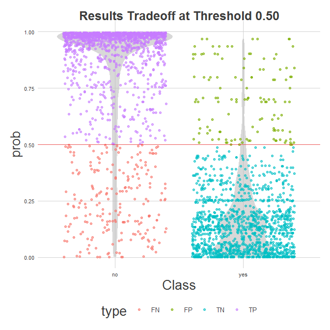

```r
plot_pred_type_distribution(df_test, threshold = 0.5)
```

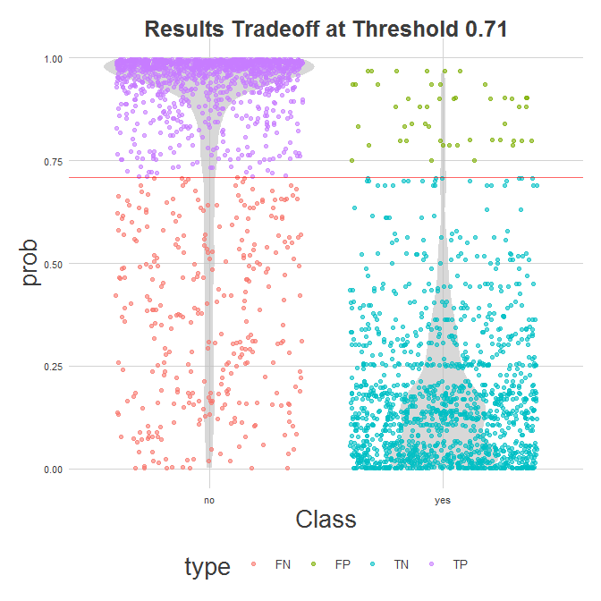

```r
plot_pred_type_distribution(df_test, threshold = 0.71)
```

```r
model_sensitivity_tbl <- confusionMatrix(reference = as.factor(pull(Y_test)) , data = mars1_pred_class_test, positive = "yes")[4] %>%
  list2DF()%>%
  head(n=1) %>% add_column(Model_type = "Mars1")

model_sensitivity_tbl
```

|  | byClass | Model_type |
| --- | --- | --- |
| 1 | 0.837037 | Mars1 |

## MARS Model 2 (inc. tuneGrid)

took more than 2 minute to run

```r
# set.seed(123)
#
# tune_params <- expand.grid(nprune = c(3,7,10,14,18,25),
#                            degree = 1)
#
# system.time(
# model_mars_2_pp_both_smpl <- train(pull(y) ~ duration+nr.employed+euribor3m+emp.var.rate+cons.conf.idx+previous+contact.telephone,
#                       data = train_both_sample,
#                       method = "earth",
#                       tuneGrid =  tune_params,
#                       metric = "Spec",
#                       trControl = fitCtrl
#                       )
# )
```

```r
# saveRDS(model_mars_2_pp_both_smpl,"model_mars_2_pp_both_smpl.rds")

# model_mars_2_pp_both_smpl <- readRDS("model_mars_2_pp_both_smpl.rds")
```

```r
# model_mars_2_pp_both_smpl
```

## MARS Model 3 (incr. features)

[1] “duration” “age” “campaign”  
[4] “euribor3m” “cons.conf.idx” “cons.price.idx”  
[7] “nr.employed” “housing.no” “housing.yes”  
[10] “day_of_week.thu” “emp.var.rate” “marital.single”  
[13] “education.high.school” “day_of_week.mon” “job.technician”

took less than 3 minute to run

```r
set.seed(123)

system.time(
model_mars_3_pp_both_smpl <- train(pull(y) ~ duration+age+campaign+euribor3m+cons.conf.idx+cons.price.idx+nr.employed+housing.no+housing.yes+day_of_week.thu+emp.var.rate+marital.single+education.high.school+day_of_week.mon+job.technician,
                      data = train_both_sample,
                      method = "earth",
                      tuneLength = 10,
                      metric = "Spec",
                      trControl = fitCtrl,
                      # preProcess = c("center","scale")
                      )
)
```

```r
# saveRDS(model_mars_3_pp_both_smpl,"model_mars_3_pp_both_smpl.rds")

model_mars_3_pp_both_smpl <- readRDS("model_mars_3_pp_both_smpl.rds")
```

```r
model_mars_3_pp_both_smpl
```

```
Multivariate Adaptive Regression Spline

2884 samples
  15 predictor
   2 classes: 'no', 'yes'

No pre-processing
Resampling: Cross-Validated (10 fold)
Summary of sample sizes: 2595, 2596, 2595, 2596, 2596, 2596, ...
Resampling results across tuning parameters:

  nprune  ROC        Sens       Spec
   2      0.8158238  0.7438102  0.7306120
   3      0.8924359  0.7664238  0.8754301
   5      0.9263954  0.8403002  0.8790637
   6      0.9292603  0.8442870  0.8848400
   8      0.9405440  0.8556071  0.9145345
   9      0.9401012  0.8482781  0.9138098
  11      0.9403323  0.8496026  0.9181576
  12      0.9402968  0.8509272  0.9188771
  14      0.9402510  0.8555982  0.9145240
  16      0.9403484  0.8556026  0.9116255

Tuning parameter 'degree' was held constant at a value of 1
Spec was used to select the optimal model using the largest value.
The final values used for the model were nprune = 12 and degree = 1.
```

```r
mars3_pred_class_test <- predict(model_mars_3_pp_both_smpl, newdata = test, type = "raw")
table(mars3_pred_class_test)
```

```
mars3_pred_class_test
 no yes
958 277
```

```r
confusionMatrix(reference = pull(Y_test), mars3_pred_class_test, positive = "yes")
```

```
Confusion Matrix and Statistics

          Reference
Prediction  no yes
       no  939  19
       yes 161 116

               Accuracy : 0.8543
                 95% CI : (0.8333, 0.8735)
    No Information Rate : 0.8907
    P-Value [Acc > NIR] : 1

                  Kappa : 0.4878

 Mcnemar's Test P-Value : <0.0000000000000002

            Sensitivity : 0.85926
            Specificity : 0.85364
         Pos Pred Value : 0.41877
         Neg Pred Value : 0.98017
             Prevalence : 0.10931
         Detection Rate : 0.09393
   Detection Prevalence : 0.22429
      Balanced Accuracy : 0.85645

       'Positive' Class : yes
```

```r
mars3_pred_no_prob <- predict(model_mars_3_pp_both_smpl, newdata = train_both_sample, type = "prob")[,"no"]
head(mars3_pred_no_prob)
```

```
[1] 0.9945707 0.9938505 0.8493475 0.8754433 0.9775223 0.9923527
```

```r
cbind(train_both_sample$y,mars3_pred_no_prob) %>% head()
```

|  | y | mars3_pred_no_prob |
| --- | --- | --- |
| 1 | no | 0.9945707 |
| 2 | no | 0.9938505 |
| 3 | no | 0.8493475 |
| 4 | no | 0.8754433 |
| 5 | no | 0.9775223 |
| 6 | no | 0.9923527 |

```r
df_test <- cbind(mars3_pred_no_prob, train_both_sample$y) %>%
            rename(prob = mars3_pred_no_prob, Class = y)

df_test <- as.data.frame(df_test)

head(df_test)
```

|  | prob | Class |
| --- | --- | --- |
| 1 | 0.9945707 | no |
| 2 | 0.9938505 | no |
| 3 | 0.8493475 | no |
| 4 | 0.8754433 | no |
| 5 | 0.9775223 | no |
| 6 | 0.9923527 | no |

## MARS Model 4 (inc. tuneGrid)

took less than 3 minute to run

```r
set.seed(123)

tune_params <- expand.grid(nprune = c(3,7,10,14,18,25,30),
                           degree = 1)

system.time(
model_mars_4_pp_both_smpl <- train(pull(y) ~ duration+age+campaign+euribor3m+cons.conf.idx+cons.price.idx+nr.employed+housing.no+housing.yes+day_of_week.thu+emp.var.rate+marital.single+education.high.school+day_of_week.mon+job.technician,
                      data = train_both_sample,
                      method = "earth",
                      tuneGrid = tune_params,
                      metric = "Spec",
                      trControl = fitCtrl
                      )
)
```

```r
# saveRDS(model_mars_4_pp_both_smpl,"model_mars_4_pp_both_smpl.rds")

model_mars_4_pp_both_smpl <- readRDS("model_mars_4_pp_both_smpl.rds")
```

```r
model_mars_4_pp_both_smpl
```

```
Multivariate Adaptive Regression Spline

2884 samples
  15 predictor
   2 classes: 'no', 'yes'

No pre-processing
Resampling: Cross-Validated (10 fold)
Summary of sample sizes: 2595, 2596, 2595, 2596, 2596, 2596, ...
Resampling results across tuning parameters:

  nprune  ROC        Sens       Spec
   3      0.8924359  0.7664238  0.8754301
   7      0.9384908  0.8615938  0.9065634
  10      0.9399183  0.8489448  0.9138046
  14      0.9402510  0.8555982  0.9145240
  18      0.9399637  0.8589316  0.9058440
  25      0.9404390  0.8602693  0.9123501
  30      0.9404390  0.8602693  0.9123501

Tuning parameter 'degree' was held constant at a value of 1
Spec was used to select the optimal model using the largest value.
The final values used for the model were nprune = 14 and degree = 1.
```

```r
mars4_pred_class_test <- predict(model_mars_4_pp_both_smpl, newdata = test, type = "raw")
table(mars4_pred_class_test)
```

```
mars4_pred_class_test
 no yes
956 279
```

```r
confusionMatrix(reference = pull(Y_test), mars4_pred_class_test, positive = "yes")
```

```
Confusion Matrix and Statistics

          Reference
Prediction  no yes
       no  937  19
       yes 163 116

               Accuracy : 0.8526
                 95% CI : (0.8316, 0.8719)
    No Information Rate : 0.8907
    P-Value [Acc > NIR] : 1

                  Kappa : 0.4844

 Mcnemar's Test P-Value : <0.0000000000000002

            Sensitivity : 0.85926
            Specificity : 0.85182
         Pos Pred Value : 0.41577
         Neg Pred Value : 0.98013
             Prevalence : 0.10931
         Detection Rate : 0.09393
   Detection Prevalence : 0.22591
      Balanced Accuracy : 0.85554

       'Positive' Class : yes
```

```r
mars4_pred_no_prob_test <- predict(model_mars_4_pp_both_smpl, newdata = test, type = "prob")[,"no"]
head(mars4_pred_no_prob_test)
```

```
[1] 0.9662850 0.4397159 0.9748790 0.9548845 0.1533306 0.9919658
```

```r
cbind(Y_test,mars4_pred_no_prob_test) %>% head()
```

|  | y | mars4_pred_no_prob_test |
| --- | --- | --- |
| 3 | no | 0.9662850 |
| 6 | no | 0.4397159 |
| 12 | no | 0.9748790 |
| 14 | no | 0.9548845 |
| 22 | yes | 0.1533306 |
| 24 | no | 0.9919658 |

```r
df_test <- cbind(mars4_pred_no_prob_test, Y_test) %>%
            rename(prob = mars4_pred_no_prob_test, Class = y)

df_test <- as.data.frame(df_test)

head(df_test)
```

|  | prob | Class |
| --- | --- | --- |
| 3 | 0.9662850 | no |
| 6 | 0.4397159 | no |
| 12 | 0.9748790 | no |
| 14 | 0.9548845 | no |
| 22 | 0.1533306 | yes |
| 24 | 0.9919658 | no |

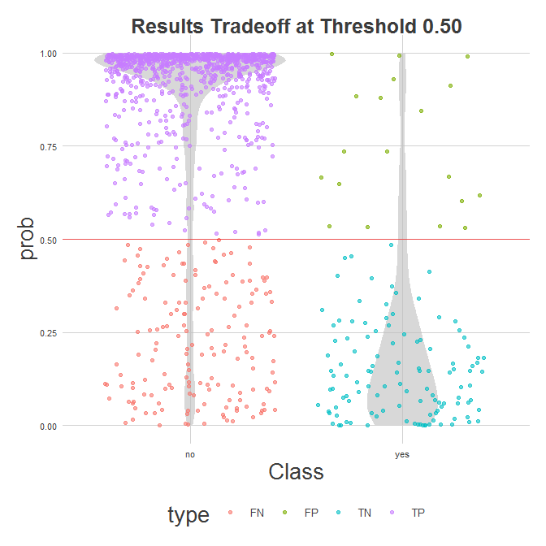

```r
plot_pred_type_distribution(df_test)
```

### VIF check

```r
library(car)
```

from: https://stats.stackexchange.com/questions/112442/what-are-aliased-coefficients

```r
alias_both_smpl_res <- alias(
  lm( as.numeric(pull(y)) ~ duration+age+campaign+euribor3m+cons.conf.idx+cons.price.idx+nr.employed+housing.no+housing.yes+day_of_week.thu+emp.var.rate+marital.single+education.high.school+day_of_week.mon+job.technician, data = train_both_sample )
  )

alias_both_smpl_res
```

```
Model :
as.numeric(pull(y)) ~ duration + age + campaign + euribor3m +
    cons.conf.idx + cons.price.idx + nr.employed + housing.no +
    housing.yes + day_of_week.thu + emp.var.rate + marital.single +
    education.high.school + day_of_week.mon + job.technician
```

```r
# saveRDS(alias_both_smpl_res, "alias_both_smpl_res.rds")

alias_both_smpl_res <- readRDS("alias_both_smpl_res.rds")
```

from: https://stackoverflow.com/questions/28885160/vifs-returning-aliased-coefficients-in-r/32791536

```r
ld.vars <- attributes(alias_both_smpl_res$Complete)$dimnames[[1]]
ld.vars
```

remove aliased variable and run model again

```r
model_vif_check_aliased <- train(as.numeric(pull(y)) ~ duration+age+campaign+euribor3m+cons.conf.idx+cons.price.idx+nr.employed+housing.no+housing.yes+day_of_week.thu+emp.var.rate+marital.single+education.high.school+day_of_week.mon+job.technician,
                      data = train_both_sample,
                      method = "lm"
                      )
```

```
You are trying to do regression and your outcome only has two possible values Are you trying to do classification? If so, use a 2 level factor as your outcome column.
```

```r
model_vif_check_aliased
```

```
Linear Regression

2884 samples
  15 predictor

No pre-processing
Resampling: Bootstrapped (25 reps)
Summary of sample sizes: 2884, 2884, 2884, 2884, 2884, 2884, ...
Resampling results:

  RMSE       Rsquared   MAE
  0.3518547  0.5049109  0.2812089

Tuning parameter 'intercept' was held constant at a value of TRUE
```

```r
# saveRDS(model_vif_check_aliased, "model_vif_check_aliased.rds")

model_vif_check_aliased <- readRDS("model_vif_check_aliased.rds")
```

```r
vif_values <- car::vif(model_vif_check_aliased$finalModel)
vif_values
```

```
             duration                   age              campaign             euribor3m
             1.026842              1.318522              1.073607             62.807538
        cons.conf.idx        cons.price.idx           nr.employed            housing.no
             2.059369              7.000131             34.526029             10.550689
          housing.yes       day_of_week.thu          emp.var.rate        marital.single
            10.506875              1.089556             30.885694              1.271858
education.high.school       day_of_week.mon        job.technician
             1.038910              1.091471              1.035240
```

```r
vif_df <- as.data.frame(vif_values)
vif_df$var_names <- rownames(vif_df)

vif_df
```

|  | vif_values | var_names |
| --- | --- | --- |
| duration | 1.026842 | duration |
| age | 1.318522 | age |
| campaign | 1.073607 | campaign |
| euribor3m | 62.807538 | euribor3m |
| cons.conf.idx | 2.059369 | cons.conf.idx |
| cons.price.idx | 7.000131 | cons.price.idx |
| nr.employed | 34.526029 | nr.employed |
| housing.no | 10.550689 | housing.no |
| housing.yes | 10.506875 | housing.yes |
| day_of_week.thu | 1.089556 | day_of_week.thu |

[output cut: 5 more lines]

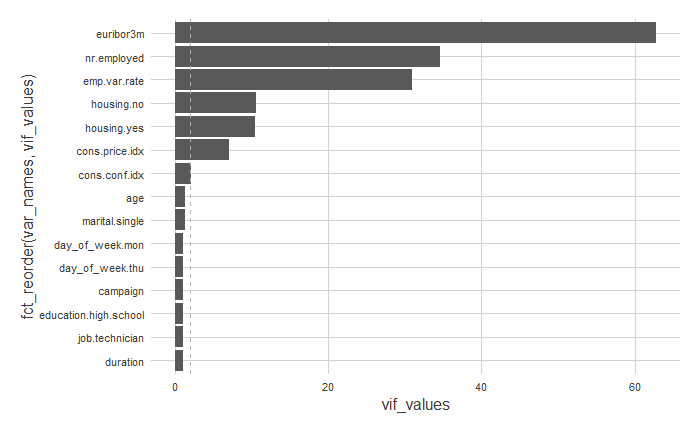

```r
vif_df %>%
  ggplot(aes(x = fct_reorder(var_names, vif_values), y =vif_values)) +
  geom_col() +
  coord_flip() +
  geom_hline(yintercept = 2, color = "gray70", lty = 2)
```

Dropping variables one by one from highest vif and recalculating vif to vif < 1.5. Maximum allowed is 2.

```r
model_vif_check_aliased <- train(as.numeric(pull(y)) ~ duration+age+campaign+cons.conf.idx+cons.price.idx+nr.employed+housing.yes+day_of_week.thu+marital.single+education.high.school+day_of_week.mon+job.technician,
                      data = train_both_sample,
                      method = "lm"
                      )
```

```
You are trying to do regression and your outcome only has two possible values Are you trying to do classification? If so, use a 2 level factor as your outcome column.
```

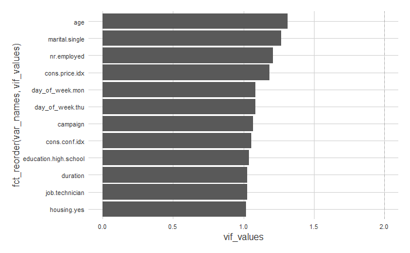

```r
vif_values <- car::vif(model_vif_check_aliased$finalModel)

vif_df <- as.data.frame(vif_values)
vif_df$var_names <- rownames(vif_df)

vif_df %>%
  ggplot(aes(x = fct_reorder(var_names, vif_values), y =vif_values)) +
  geom_col() +
  coord_flip() +
  geom_hline(yintercept = 2, color = "gray70", lty = 2)
```

## MARS Model 5 (After VIF)

```r
set.seed(123)

tune_params <- expand.grid(nprune = c(3,7,10,14,18,25,30),
                           degree = 1)

system.time(
model_mars_5_both_smpl <- train(pull(y) ~ duration+age+campaign+cons.conf.idx+cons.price.idx+nr.employed+housing.yes+day_of_week.thu+marital.single+education.high.school+day_of_week.mon+job.technician,
                      data = train_both_sample,
                      method = "earth",
                      tuneGrid = tune_params,
                      metric = "Spec",
                      trControl = fitCtrl
                      )
)
```

```r
# saveRDS(model_mars_5_both_smpl,"model_mars_5_both_smpl.rds")

model_mars_5_both_smpl <- readRDS("model_mars_5_both_smpl.rds")
```

```r
model_mars_5_both_smpl
```

```
Multivariate Adaptive Regression Spline

2884 samples
  12 predictor
   2 classes: 'no', 'yes'

No pre-processing
Resampling: Cross-Validated (10 fold)
Summary of sample sizes: 2595, 2596, 2595, 2596, 2596, 2596, ...
Resampling results across tuning parameters:

  nprune  ROC        Sens       Spec
   3      0.8876142  0.7750773  0.8515223
   7      0.9295378  0.8469448  0.8783130
  10      0.9392887  0.8436247  0.9130695
  14      0.9392868  0.8436380  0.9167084
  18      0.9396661  0.8482958  0.9145240
  25      0.9396661  0.8482958  0.9145240
  30      0.9396661  0.8482958  0.9145240

Tuning parameter 'degree' was held constant at a value of 1
Spec was used to select the optimal model using the largest value.
The final values used for the model were nprune = 14 and degree = 1.
```

### check pred. probability

```r
predict(model_mars_5_both_smpl, type = "prob") %>% head()
```

|  | no | yes |
| --- | --- | --- |
| 1 | 0.9953425 | 0.004657507 |
| 2 | 0.9901982 | 0.009801814 |
| 3 | 0.8152133 | 0.184786676 |
| 4 | 0.8308524 | 0.169147559 |
| 5 | 0.9853721 | 0.014627922 |
| 6 | 0.9959789 | 0.004021077 |

### check pred. class

```r
predict(model_mars_5_both_smpl, type = "raw") %>% head()
```

```
[1] no no no no no no
Levels: no yes
```

```r
predict(model_mars_5_both_smpl, newdata = test,type = "raw") %>% table()
```

```
.
 no yes
955 280
```

### TP,FP,TN,FN visual exploration

from: file:///E:/3.%20R/ML/tidytuesday%20Himalayan/r_Himalayan_tidytuesday-labversion.html

```r
mars5_pred_class_test <- predict(model_mars_5_both_smpl, newdata = test, type = "raw")

table(mars5_pred_class_test)
```

```
mars5_pred_class_test
 no yes
955 280
```

```r
mars5_pred_no_prob_test <- predict(model_mars_5_both_smpl, newdata = test, type = "prob")[,"no"]
head(mars5_pred_no_prob_test)
```

```
[1] 0.9555701 0.3502360 0.9737797 0.9651600 0.2002705 0.9878428
```

```r
confusionMatrix(reference = pull(Y_test), mars5_pred_class_test)
```

```
Confusion Matrix and Statistics

          Reference
Prediction  no yes
       no  934  21
       yes 166 114

               Accuracy : 0.8486
                 95% CI : (0.8274, 0.8681)
    No Information Rate : 0.8907
    P-Value [Acc > NIR] : 1

                  Kappa : 0.4714

 Mcnemar's Test P-Value : <0.0000000000000002

            Sensitivity : 0.8491
            Specificity : 0.8444
         Pos Pred Value : 0.9780
         Neg Pred Value : 0.4071
             Prevalence : 0.8907
         Detection Rate : 0.7563
   Detection Prevalence : 0.7733
      Balanced Accuracy : 0.8468

       'Positive' Class : no
```

```r
cbind(Y_test,mars5_pred_no_prob_test) %>% head()
```

|  | y | mars5_pred_no_prob_test |
| --- | --- | --- |
| 3 | no | 0.9555701 |
| 6 | no | 0.3502360 |
| 12 | no | 0.9737797 |
| 14 | no | 0.9651600 |
| 22 | yes | 0.2002705 |
| 24 | no | 0.9878428 |

```r
df_test <- cbind(mars5_pred_no_prob_test, Y_test) %>%
            rename(prob = mars5_pred_no_prob_test, Class = y)

df_test <- as.data.frame(df_test)

head(df_test)
```

|  | prob | Class |
| --- | --- | --- |
| 3 | 0.9555701 | no |
| 6 | 0.3502360 | no |
| 12 | 0.9737797 | no |
| 14 | 0.9651600 | no |
| 22 | 0.2002705 | yes |
| 24 | 0.9878428 | no |

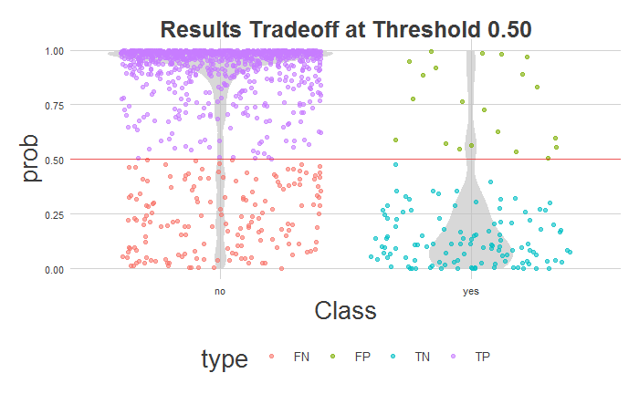

```r
plot_pred_type_distribution(df_test, threshold = 0.5)
```

### change threshold

from: https://stackoverflow.com/questions/32128879/how-to-change-the-threshold-for-binary-classification

```r
confusionMatrix(table(predict(model_mars_5_both_smpl, type="prob")[,"yes"] >= 0.25,
                      train_both_sample$y == "yes"))
```

```
Confusion Matrix and Statistics


        FALSE TRUE
  FALSE  1161   52
  TRUE    342 1329

               Accuracy : 0.8634
                 95% CI : (0.8503, 0.8757)
    No Information Rate : 0.5212
    P-Value [Acc > NIR] : < 0.00000000000000022

                  Kappa : 0.7286

 Mcnemar's Test P-Value : < 0.00000000000000022

            Sensitivity : 0.7725
            Specificity : 0.9623
         Pos Pred Value : 0.9571
         Neg Pred Value : 0.7953
             Prevalence : 0.5212
         Detection Rate : 0.4026
   Detection Prevalence : 0.4206
      Balanced Accuracy : 0.8674

       'Positive' Class : FALSE
```

As we can see above by changing the threshold it is increasing the `specificity` at the cost of lower `sensitvity` and lower `accuracy`

```r
threshold_confmatrix <- function(threshold_major_class = 0.5){
  confusionMatrix(table(predict(model_mars_5_both_smpl, type="prob")[,"yes"] >= (1- threshold_major_class),
                      train_both_sample$y == "yes"))
}
```

```r
threshold_confmatrix(0.75)
```

```
Confusion Matrix and Statistics


        FALSE TRUE
  FALSE  1161   52
  TRUE    342 1329

               Accuracy : 0.8634
                 95% CI : (0.8503, 0.8757)
    No Information Rate : 0.5212
    P-Value [Acc > NIR] : < 0.00000000000000022

                  Kappa : 0.7286

 Mcnemar's Test P-Value : < 0.00000000000000022

            Sensitivity : 0.7725
            Specificity : 0.9623
         Pos Pred Value : 0.9571
         Neg Pred Value : 0.7953
             Prevalence : 0.5212
         Detection Rate : 0.4026
   Detection Prevalence : 0.4206
      Balanced Accuracy : 0.8674

       'Positive' Class : FALSE
```

### change threshold (did not work)

from: https://stats.stackexchange.com/questions/112388/how-to-change-threshold-for-classification-in-r-randomforests

```r
mars5_pred_yes <- predict(model_mars_5_both_smpl, newdata = test, type = "prob")["yes"]

cutoff = 0.3

mars5_pred_yes[mars5_pred_yes > cutoff] = "yes"
mars5_pred_yes[mars5_pred_yes < cutoff] = "no"

mars5_pred_yes %>%  head()
```

```r
confusionMatrix(reference = pull(Y_test), as.factor(pull(mars5_pred_yes)), positive = "yes")
```

```
Confusion Matrix and Statistics

          Reference
Prediction  no yes
       no  883  12
       yes 217 123

               Accuracy : 0.8146
                 95% CI : (0.7918, 0.8359)
    No Information Rate : 0.8907
    P-Value [Acc > NIR] : 1

                  Kappa : 0.4285

 Mcnemar's Test P-Value : <0.0000000000000002

            Sensitivity : 0.9111
            Specificity : 0.8027
         Pos Pred Value : 0.3618
         Neg Pred Value : 0.9866
             Prevalence : 0.1093
         Detection Rate : 0.0996
   Detection Prevalence : 0.2753
      Balanced Accuracy : 0.8569

       'Positive' Class : yes
```

```r
threshold_fn <- function(model_name = model_mars_5_both_smpl, cutoff__prob_yes = 0.3) {

  model_prediction <- predict({{model_name}}, newdata = test, type = "prob")["yes"]
  # cutoff__prob_yes = 0.3

  model_prediction[model_prediction > cutoff__prob_yes] = "yes"
  model_prediction[model_prediction < cutoff__prob_yes] = "no"

  # model_prediction %>%  head()

  confusionMatrix(reference = pull(Y_test), as.factor(pull(model_prediction)), positive = "yes")
}
```

```r
threshold_fn(model_mars_1_both_smpl, cutoff__prob_yes = .4)
```

```
Confusion Matrix and Statistics

          Reference
Prediction  no yes
       no  911  17
       yes 189 118

               Accuracy : 0.8332
                 95% CI : (0.8112, 0.8536)
    No Information Rate : 0.8907
    P-Value [Acc > NIR] : 1

                  Kappa : 0.4505

 Mcnemar's Test P-Value : <0.0000000000000002

            Sensitivity : 0.87407
            Specificity : 0.82818
         Pos Pred Value : 0.38436
         Neg Pred Value : 0.98168
             Prevalence : 0.10931
         Detection Rate : 0.09555
   Detection Prevalence : 0.24858
      Balanced Accuracy : 0.85113

       'Positive' Class : yes
```

### Test Data Mars Model 5

```r
mars5_pred_class_test <- predict(model_mars_5_both_smpl, newdata = test,type = "raw")

mars5_pred_class_test %>% table()
```

```
.
 no yes
955 280
```

```r
mars5_pred_no_prob_test <- predict(model_mars_5_both_smpl, newdata = test, type = "prob")[,"no"]

head(mars5_pred_no_prob_test)
```

```
[1] 0.9555701 0.3502360 0.9737797 0.9651600 0.2002705 0.9878428
```

```r
df_test <- cbind(mars5_pred_no_prob_test, Y_test) %>%
            rename(prob = mars5_pred_no_prob_test, Class = y)

df_test <- as.data.frame(df_test)

head(df_test)
```

|  | prob | Class |
| --- | --- | --- |
| 3 | 0.9555701 | no |
| 6 | 0.3502360 | no |
| 12 | 0.9737797 | no |
| 14 | 0.9651600 | no |
| 22 | 0.2002705 | yes |
| 24 | 0.9878428 | no |

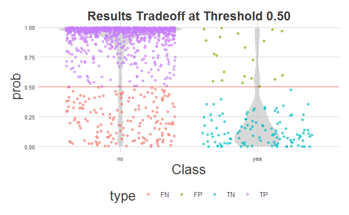

```r
plot_pred_type_distribution(df_test, threshold = 0.5)
```

```r
confusionMatrix(reference = as.factor(pull(Y_test)) , data = mars5_pred_class_test, positive = "yes")
```

```
Confusion Matrix and Statistics

          Reference
Prediction  no yes
       no  934  21
       yes 166 114

               Accuracy : 0.8486
                 95% CI : (0.8274, 0.8681)
    No Information Rate : 0.8907
    P-Value [Acc > NIR] : 1

                  Kappa : 0.4714

 Mcnemar's Test P-Value : <0.0000000000000002

            Sensitivity : 0.84444
            Specificity : 0.84909
         Pos Pred Value : 0.40714
         Neg Pred Value : 0.97801
             Prevalence : 0.10931
         Detection Rate : 0.09231
   Detection Prevalence : 0.22672
      Balanced Accuracy : 0.84677

       'Positive' Class : yes
```

```r
confusionMatrix(reference = as.factor(pull(Y_test)) , data = mars5_pred_class_test, positive = "yes")[4]
```

```
$byClass
         Sensitivity          Specificity       Pos Pred Value       Neg Pred Value
          0.84444444           0.84909091           0.40714286           0.97801047
           Precision               Recall                   F1           Prevalence
          0.40714286           0.84444444           0.54939759           0.10931174
      Detection Rate Detection Prevalence    Balanced Accuracy
          0.09230769           0.22672065           0.84676768
```

```r
model_sensitivity_tbl <- confusionMatrix(reference = as.factor(pull(Y_test)) , data = mars5_pred_class_test, positive = "yes")[4] %>%
  list2DF()%>%
  head(n=1) %>%
  add_column(Model_type = "Mars5") %>%
  rbind(model_sensitivity_tbl)

model_sensitivity_tbl
```

| byClass | Model_type |
| --- | --- |
| 0.8444444 | Mars5 |
| 0.8370370 | Mars1 |

## Adaboost Model

```r
set.seed(123)

system.time(
model_adaboost_1_both_smpl <- train(pull(y) ~ duration+age+campaign+cons.conf.idx+cons.price.idx+nr.employed+housing.yes+day_of_week.thu+marital.single+education.high.school+day_of_week.mon+job.technician,
                        data = train_both_sample,
                        method = "adaboost",
                        tuneLenth = 10,
                        metric = "Spec",
                        trControl = fitCtrl)
)
```

```r
# saveRDS(model_adaboost_1_both_smpl,"model_adaboost_1_both_smpl.rds")

model_adaboost_1_both_smpl <- readRDS("model_adaboost_1_both_smpl.rds")
```

```r
model_adaboost_1_both_smpl
```

```
AdaBoost Classification Trees

2884 samples
  12 predictor
   2 classes: 'no', 'yes'

No pre-processing
Resampling: Cross-Validated (10 fold)
Summary of sample sizes: 2595, 2596, 2595, 2596, 2596, 2596, ...
Resampling results across tuning parameters:

  nIter  method         ROC        Sens       Spec
   50    Adaboost.M1    0.9928736  0.9427947  0.9920290
   50    Real adaboost  0.8801475  0.9500927  0.9905797
  100    Adaboost.M1    0.9953687  0.9454481  0.9913043
  100    Real adaboost  0.8560594  0.9514437  0.9884058
  150    Adaboost.M1    0.9957649  0.9481060  0.9905797
  150    Real adaboost  0.8566791  0.9540971  0.9898551

Spec was used to select the optimal model using the largest value.
The final values used for the model were nIter = 50 and method = Adaboost.M1.
```

### Test Data Adaboost

```r
adaboost1_pred_class_test <- predict(model_adaboost_1_both_smpl, newdata = test,type = "raw")

adaboost1_pred_class_test %>% table()
```

```
.
  no  yes
1041  194
```

```r
adaboost1_pred_no_prob_test <- predict(model_mars_5_both_smpl, newdata = test, type = "prob")[,"no"]

head(adaboost1_pred_no_prob_test)
```

```
[1] 0.9555701 0.3502360 0.9737797 0.9651600 0.2002705 0.9878428
```

```r
df_test <- cbind(adaboost1_pred_no_prob_test, Y_test) %>%
            rename(prob = adaboost1_pred_no_prob_test, Class = y)

df_test <- as.data.frame(df_test)

head(df_test)
```

|  | prob | Class |
| --- | --- | --- |
| 3 | 0.9555701 | no |
| 6 | 0.3502360 | no |
| 12 | 0.9737797 | no |
| 14 | 0.9651600 | no |
| 22 | 0.2002705 | yes |
| 24 | 0.9878428 | no |

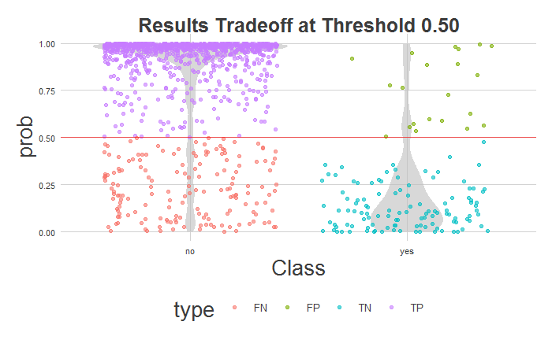

```r
plot_pred_type_distribution(df_test, threshold = 0.5)
```

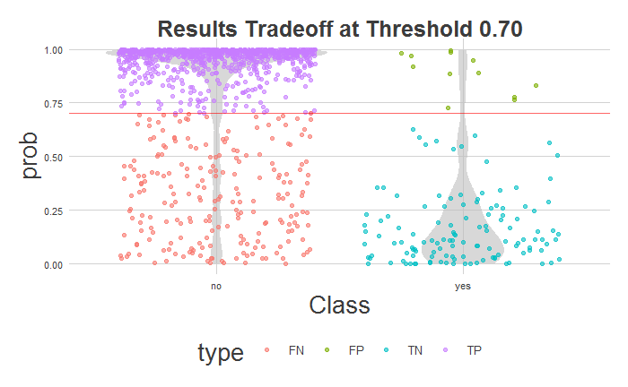

```r
plot_pred_type_distribution(df_test, threshold = 0.7)
```

```r
threshold_fn(model_name = model_adaboost_1_both_smpl, cutoff__prob_yes = .5)
```

```
Confusion Matrix and Statistics

          Reference
Prediction   no  yes
       no  1005   42
       yes   95   93

               Accuracy : 0.8891
                 95% CI : (0.8702, 0.906)
    No Information Rate : 0.8907
    P-Value [Acc > NIR] : 0.5945

                  Kappa : 0.514

 Mcnemar's Test P-Value : 0.000008885

            Sensitivity : 0.6889
            Specificity : 0.9136
         Pos Pred Value : 0.4947
         Neg Pred Value : 0.9599
             Prevalence : 0.1093
         Detection Rate : 0.0753
   Detection Prevalence : 0.1522
      Balanced Accuracy : 0.8013

       'Positive' Class : yes
```

```r
threshold_fn(model_name = model_adaboost_1_both_smpl, cutoff__prob_yes = .3)
```

```
Confusion Matrix and Statistics

          Reference
Prediction  no yes
       no  915  21
       yes 185 114

               Accuracy : 0.8332
                 95% CI : (0.8112, 0.8536)
    No Information Rate : 0.8907
    P-Value [Acc > NIR] : 1

                  Kappa : 0.4412

 Mcnemar's Test P-Value : <0.0000000000000002

            Sensitivity : 0.84444
            Specificity : 0.83182
         Pos Pred Value : 0.38127
         Neg Pred Value : 0.97756
             Prevalence : 0.10931
         Detection Rate : 0.09231
   Detection Prevalence : 0.24211
      Balanced Accuracy : 0.83813

       'Positive' Class : yes
```

```r
confusionMatrix(reference = as.factor(pull(Y_test)) , data = adaboost1_pred_class_test, positive = "yes")
```

```
Confusion Matrix and Statistics

          Reference
Prediction   no  yes
       no  1002   39
       yes   98   96

               Accuracy : 0.8891
                 95% CI : (0.8702, 0.906)
    No Information Rate : 0.8907
    P-Value [Acc > NIR] : 0.5945

                  Kappa : 0.522

 Mcnemar's Test P-Value : 0.0000007223

            Sensitivity : 0.71111
            Specificity : 0.91091
         Pos Pred Value : 0.49485
         Neg Pred Value : 0.96254
             Prevalence : 0.10931
         Detection Rate : 0.07773
   Detection Prevalence : 0.15709
      Balanced Accuracy : 0.81101

       'Positive' Class : yes
```

```r
model_sensitivity_tbl <- confusionMatrix(reference = as.factor(pull(Y_test)) , data = adaboost1_pred_class_test, positive = "yes")[4] %>%
  list2DF()%>%
  head(n=1) %>%
  add_column(Model_type = "Adaboost") %>%
  rbind(model_sensitivity_tbl)

model_sensitivity_tbl
```

| byClass | Model_type |
| --- | --- |
| 0.7111111 | Adaboost |
| 0.8444444 | Mars5 |
| 0.8370370 | Mars1 |

## Knn Model

```r
set.seed(123)

system.time(
model_knn_both_smpl <- train(pull(y) ~
duration+age+campaign+cons.conf.idx+cons.price.idx+nr.employed+housing.yes+day_of_week.thu+marital.single+education.high.school+day_of_week.mon+job.technician,
                        data = train_both_sample,
                        method = "kknn",
                        tuneLenth = 10,
                        metric = "Spec",
                        trControl = fitCtrl)
)
```

```r
# saveRDS(model_knn_both_smpl,"model_knn_both_smpl.rds")

model_knn_both_smpl <- readRDS("model_knn_both_smpl.rds")
```

```r
model_knn_both_smpl
```

```
k-Nearest Neighbors

2884 samples
  12 predictor
   2 classes: 'no', 'yes'

No pre-processing
Resampling: Cross-Validated (10 fold)
Summary of sample sizes: 2595, 2596, 2595, 2596, 2596, 2596, ...
Resampling results across tuning parameters:

  kmax  ROC        Sens       Spec
  5     0.9648132  0.9441192  0.9855072
  7     0.9648132  0.9441192  0.9855072
  9     0.9648132  0.9441192  0.9855072

Tuning parameter 'distance' was held constant at a value of 2
Tuning parameter 'kernel' was
 held constant at a value of optimal
Spec was used to select the optimal model using the largest value.
The final values used for the model were kmax = 9, distance = 2 and kernel = optimal.
```

### Test Data knn

```r
knn_pred_class_test <- predict(model_knn_both_smpl, newdata = test,type = "raw")

knn_pred_class_test %>% table()
```

```
.
  no  yes
1067  168
```

```r
knn_pred_no_prob_test <- predict(model_knn_both_smpl, newdata = test, type = "prob")[,"no"]

head(knn_pred_no_prob_test)
```

```
[1] 1 1 1 1 0 1
```

```r
confusionMatrix(reference = as.factor(pull(Y_test)) , data = knn_pred_class_test, positive = "yes")
```

```
Confusion Matrix and Statistics

          Reference
Prediction   no  yes
       no  1002   65
       yes   98   70

               Accuracy : 0.868
                 95% CI : (0.8479, 0.8864)
    No Information Rate : 0.8907
    P-Value [Acc > NIR] : 0.9944

                  Kappa : 0.3878

 Mcnemar's Test P-Value : 0.0122

            Sensitivity : 0.51852
            Specificity : 0.91091
         Pos Pred Value : 0.41667
         Neg Pred Value : 0.93908
             Prevalence : 0.10931
         Detection Rate : 0.05668
   Detection Prevalence : 0.13603
      Balanced Accuracy : 0.71471

       'Positive' Class : yes
```

```r
df_test <- cbind(knn_pred_no_prob_test, Y_test) %>%
            rename(prob = knn_pred_no_prob_test, Class = y)

df_test <- as.data.frame(df_test)

head(df_test)
```

|  | prob | Class |
| --- | --- | --- |
| 3 | 1 | no |
| 6 | 1 | no |
| 12 | 1 | no |
| 14 | 1 | no |
| 22 | 0 | yes |
| 24 | 1 | no |

[figure not shown]

```r
threshold_fn(model_knn_both_smpl, cutoff__prob_yes = .5)
```

```
Confusion Matrix and Statistics

          Reference
Prediction   no  yes
       no  1002   65
       yes   98   70

               Accuracy : 0.868
                 95% CI : (0.8479, 0.8864)
    No Information Rate : 0.8907
    P-Value [Acc > NIR] : 0.9944

                  Kappa : 0.3878

 Mcnemar's Test P-Value : 0.0122

            Sensitivity : 0.51852
            Specificity : 0.91091
         Pos Pred Value : 0.41667
         Neg Pred Value : 0.93908
             Prevalence : 0.10931
         Detection Rate : 0.05668
   Detection Prevalence : 0.13603
      Balanced Accuracy : 0.71471

       'Positive' Class : yes
```

```r
threshold_fn(model_knn_both_smpl, cutoff__prob_yes = .3)
```

```
Confusion Matrix and Statistics

          Reference
Prediction   no  yes
       no  1002   65
       yes   98   70

               Accuracy : 0.868
                 95% CI : (0.8479, 0.8864)
    No Information Rate : 0.8907
    P-Value [Acc > NIR] : 0.9944

                  Kappa : 0.3878

 Mcnemar's Test P-Value : 0.0122

            Sensitivity : 0.51852
            Specificity : 0.91091
         Pos Pred Value : 0.41667
         Neg Pred Value : 0.93908
             Prevalence : 0.10931
         Detection Rate : 0.05668
   Detection Prevalence : 0.13603
      Balanced Accuracy : 0.71471

       'Positive' Class : yes
```

[figure not shown]

```r
threshold_fn(model_knn_both_smpl, cutoff__prob_yes = .2)
```

```
Confusion Matrix and Statistics

          Reference
Prediction   no  yes
       no  1002   65
       yes   98   70

               Accuracy : 0.868
                 95% CI : (0.8479, 0.8864)
    No Information Rate : 0.8907
    P-Value [Acc > NIR] : 0.9944

                  Kappa : 0.3878

 Mcnemar's Test P-Value : 0.0122

            Sensitivity : 0.51852
            Specificity : 0.91091
         Pos Pred Value : 0.41667
         Neg Pred Value : 0.93908
             Prevalence : 0.10931
         Detection Rate : 0.05668
   Detection Prevalence : 0.13603
      Balanced Accuracy : 0.71471

       'Positive' Class : yes
```

For some reason by changing probability in knn is not changing the results. This might be due to as this algorithm works on distance.

```r
model_sensitivity_tbl <- confusionMatrix(reference = as.factor(pull(Y_test)) , data = knn_pred_class_test, positive = "yes")[4] %>%
  list2DF()%>%
  head(n=1) %>%
  add_column(Model_type = "knn") %>%
  rbind(model_sensitivity_tbl)

model_sensitivity_tbl
```

| byClass | Model_type |
| --- | --- |
| 0.5185185 | knn |
| 0.7111111 | Adaboost |
| 0.8444444 | Mars5 |
| 0.8370370 | Mars1 |

## DT Model

from: https://rpubs.com/maulikpatel/229337

```r
set.seed(123)

system.time(
model_dt_both_smpl <- train(pull(y) ~
duration+age+campaign+cons.conf.idx+cons.price.idx+nr.employed+housing.yes+day_of_week.thu+marital.single+education.high.school+day_of_week.mon+job.technician,
                        data = train_both_sample,
                        method = "rpart",
                        # tuneLenth = 10,  # tunLength with Dt gives errors
                        metric = "Spec",
                        trControl = fitCtrl)
)
```

```r
# saveRDS(model_dt_both_smpl,"model_dt_both_smpl.rds")

model_dt_both_smpl <- readRDS("model_dt_both_smpl.rds")
```

```r
model_dt_both_smpl
```

```
CART

2884 samples
  12 predictor
   2 classes: 'no', 'yes'

No pre-processing
Resampling: Cross-Validated (10 fold)
Summary of sample sizes: 2595, 2596, 2595, 2596, 2596, 2596, ...
Resampling results across tuning parameters:

  cp          ROC        Sens       Spec
  0.03403331  0.8716966  0.7851038  0.9239756
  0.18754526  0.7810018  0.7610552  0.7942290
  0.47429399  0.6100858  0.9042296  0.3159420

Spec was used to select the optimal model using the largest value.
The final value used for the model was cp = 0.03403331.
```

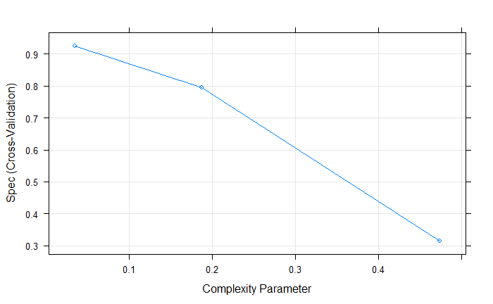

```r
plot(model_dt_both_smpl)
```

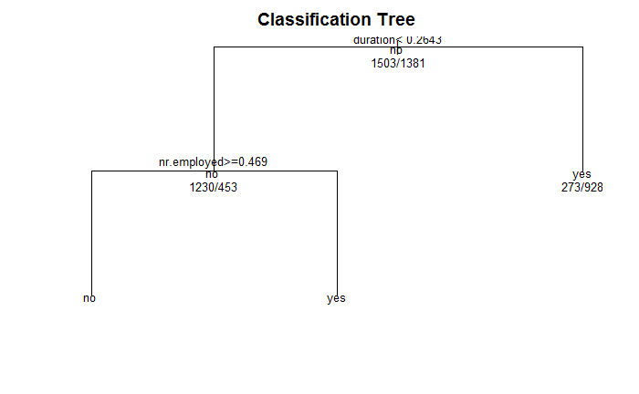

```r
# from: https://rpubs.com/maulikpatel/229337

plot(model_dt_both_smpl$finalModel,
     uniform = TRUE,
     main = "Classification Tree")

text(model_dt_both_smpl$finalModel, use.n = TRUE, all = TRUE, cex = .8)
```

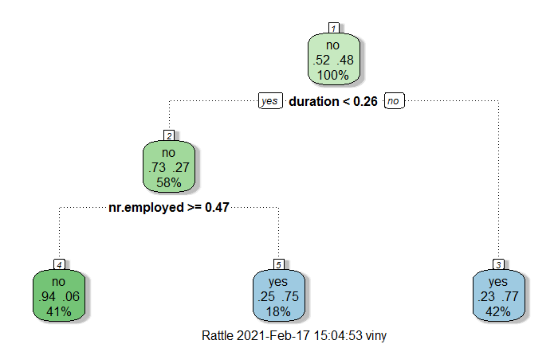

```r
# install.packages("rattle")

library(rattle)
fancyRpartPlot(model_dt_both_smpl$finalModel)
```

### Test Data DT

```r
dt_pred_class_test <- predict(model_dt_both_smpl, newdata = test,type = "raw")

dt_pred_class_test %>% table()
```

```
.
 no yes
839 396
```

```r
dt_pred_no_prob_test <- predict(model_dt_both_smpl, newdata = test, type = "prob")[,"no"]

head(dt_pred_no_prob_test)
```

```
[1] 0.9412266 0.2455796 0.9412266 0.9412266 0.2455796 0.9412266
```

```r
confusionMatrix(reference = as.factor(pull(Y_test)) , data = dt_pred_class_test, positive = "yes")
```

```
Confusion Matrix and Statistics

          Reference
Prediction  no yes
       no  826  13
       yes 274 122

               Accuracy : 0.7676
                 95% CI : (0.743, 0.7909)
    No Information Rate : 0.8907
    P-Value [Acc > NIR] : 1

                  Kappa : 0.3542

 Mcnemar's Test P-Value : <0.0000000000000002

            Sensitivity : 0.90370
            Specificity : 0.75091
         Pos Pred Value : 0.30808
         Neg Pred Value : 0.98451
             Prevalence : 0.10931
         Detection Rate : 0.09879
   Detection Prevalence : 0.32065
      Balanced Accuracy : 0.82731

       'Positive' Class : yes
```

```r
df_test <- cbind(dt_pred_no_prob_test, Y_test) %>%
            rename(prob = dt_pred_no_prob_test, Class = y)

df_test <- as.data.frame(df_test)

head(df_test)
```

|  | prob | Class |
| --- | --- | --- |
| 3 | 0.9412266 | no |
| 6 | 0.2455796 | no |
| 12 | 0.9412266 | no |
| 14 | 0.9412266 | no |
| 22 | 0.2455796 | yes |
| 24 | 0.9412266 | no |

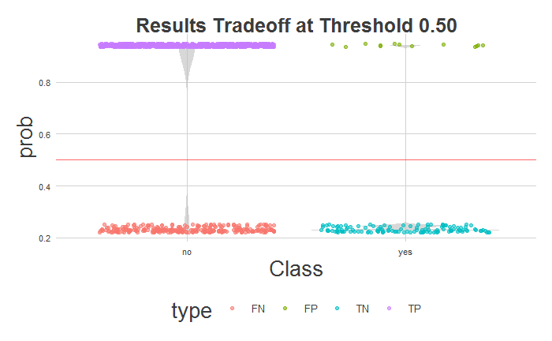

```r
plot_pred_type_distribution(df_test, threshold = 0.5)
```

```r
threshold_fn(model_dt_both_smpl, cutoff__prob_yes = .3)
```

```
Confusion Matrix and Statistics

          Reference
Prediction  no yes
       no  826  13
       yes 274 122

               Accuracy : 0.7676
                 95% CI : (0.743, 0.7909)
    No Information Rate : 0.8907
    P-Value [Acc > NIR] : 1

                  Kappa : 0.3542

 Mcnemar's Test P-Value : <0.0000000000000002

            Sensitivity : 0.90370
            Specificity : 0.75091
         Pos Pred Value : 0.30808
         Neg Pred Value : 0.98451
             Prevalence : 0.10931
         Detection Rate : 0.09879
   Detection Prevalence : 0.32065
      Balanced Accuracy : 0.82731

       'Positive' Class : yes
```

```r
model_sensitivity_tbl <- confusionMatrix(reference = as.factor(pull(Y_test)) , data = dt_pred_class_test, positive = "yes")[4] %>%
  list2DF()%>%
  head(n=1) %>%
  add_column(Model_type = "DT") %>%
  rbind(model_sensitivity_tbl)

model_sensitivity_tbl
```

| byClass | Model_type |
| --- | --- |
| 0.9037037 | DT |
| 0.5185185 | knn |
| 0.7111111 | Adaboost |
| 0.8444444 | Mars5 |
| 0.8370370 | Mars1 |

## RF Model

```r
set.seed(123)

system.time(
model_rf_both_smpl <- train(pull(y) ~
duration+age+campaign+cons.conf.idx+cons.price.idx+nr.employed+housing.yes+day_of_week.thu+marital.single+education.high.school+day_of_week.mon+job.technician,
                        data = train_both_sample,
                        method = "rf",
                        tuneLenth = 10,
                        metric = "Spec",
                        trControl = fitCtrl)
)
```

```r
# saveRDS(model_rf_both_smpl,"model_rf_both_smpl.rds")

model_rf_both_smpl <- readRDS("model_rf_both_smpl.rds")
```

```r
model_rf_both_smpl
```

```
Random Forest

2884 samples
  12 predictor
   2 classes: 'no', 'yes'

No pre-processing
Resampling: Cross-Validated (10 fold)
Summary of sample sizes: 2595, 2596, 2595, 2596, 2596, 2596, ...
Resampling results across tuning parameters:

  mtry  ROC        Sens       Spec
   2    0.9951305  0.9234834  0.9898603
   7    0.9968891  0.9374658  0.9920342
  12    0.9960675  0.9381325  0.9913096

Spec was used to select the optimal model using the largest value.
The final value used for the model was mtry = 7.
```

### Test Data RF

```r
rf_pred_class_test <- predict(model_rf_both_smpl, newdata = test,type = "raw")

rf_pred_class_test %>% table()
```

```
.
  no  yes
1030  205
```

```r
rf_pred_no_prob_test <- predict(model_rf_both_smpl, newdata = test, type = "prob")[,"no"]

head(rf_pred_no_prob_test)
```

```
[1] 0.660 0.672 1.000 0.998 0.408 1.000
```

```r
confusionMatrix(reference = as.factor(pull(Y_test)) , data = rf_pred_class_test, positive = "yes")
```

```
Confusion Matrix and Statistics

          Reference
Prediction  no yes
       no  994  36
       yes 106  99

               Accuracy : 0.885
                 95% CI : (0.8659, 0.9023)
    No Information Rate : 0.8907
    P-Value [Acc > NIR] : 0.755

                  Kappa : 0.5189

 Mcnemar's Test P-Value : 0.000000007024

            Sensitivity : 0.73333
            Specificity : 0.90364
         Pos Pred Value : 0.48293
         Neg Pred Value : 0.96505
             Prevalence : 0.10931
         Detection Rate : 0.08016
   Detection Prevalence : 0.16599
      Balanced Accuracy : 0.81848

       'Positive' Class : yes
```

```r
df_test <- cbind(rf_pred_no_prob_test, Y_test) %>%
            rename(prob = rf_pred_no_prob_test, Class = y)

df_test <- as.data.frame(df_test)

head(df_test)
```

|  | prob | Class |
| --- | --- | --- |
| 3 | 0.660 | no |
| 6 | 0.672 | no |
| 12 | 1.000 | no |
| 14 | 0.998 | no |
| 22 | 0.408 | yes |
| 24 | 1.000 | no |

[figure not shown]

```r
threshold_fn(model_rf_both_smpl, cutoff__prob_yes = 0.3)
```

```
Confusion Matrix and Statistics

          Reference
Prediction  no yes
       no  935  21
       yes 165 114

               Accuracy : 0.8494
                 95% CI : (0.8282, 0.8689)
    No Information Rate : 0.8907
    P-Value [Acc > NIR] : 1

                  Kappa : 0.4731

 Mcnemar's Test P-Value : <0.0000000000000002

            Sensitivity : 0.84444
            Specificity : 0.85000
         Pos Pred Value : 0.40860
         Neg Pred Value : 0.97803
             Prevalence : 0.10931
         Detection Rate : 0.09231
   Detection Prevalence : 0.22591
      Balanced Accuracy : 0.84722

       'Positive' Class : yes
```

[figure not shown]

```r
threshold_fn(model_rf_both_smpl, cutoff__prob_yes = 0.2)
```

```
Confusion Matrix and Statistics

          Reference
Prediction  no yes
       no  892  18
       yes 208 117

               Accuracy : 0.817
                 95% CI : (0.7943, 0.8382)
    No Information Rate : 0.8907
    P-Value [Acc > NIR] : 1

                  Kappa : 0.4189

 Mcnemar's Test P-Value : <0.0000000000000002

            Sensitivity : 0.86667
            Specificity : 0.81091
         Pos Pred Value : 0.36000
         Neg Pred Value : 0.98022
             Prevalence : 0.10931
         Detection Rate : 0.09474
   Detection Prevalence : 0.26316
      Balanced Accuracy : 0.83879

       'Positive' Class : yes
```

```r
threshold_fn(model_rf_both_smpl, cutoff__prob_yes = 0.18)
```

```
Confusion Matrix and Statistics

          Reference
Prediction  no yes
       no  885  16
       yes 215 119

               Accuracy : 0.813
                 95% CI : (0.7901, 0.8343)
    No Information Rate : 0.8907
    P-Value [Acc > NIR] : 1

                  Kappa : 0.4166

 Mcnemar's Test P-Value : <0.0000000000000002

            Sensitivity : 0.88148
            Specificity : 0.80455
         Pos Pred Value : 0.35629
         Neg Pred Value : 0.98224
             Prevalence : 0.10931
         Detection Rate : 0.09636
   Detection Prevalence : 0.27045
      Balanced Accuracy : 0.84301

       'Positive' Class : yes
```

```r
model_sensitivity_tbl <- confusionMatrix(reference = as.factor(pull(Y_test)) , data = rf_pred_class_test, positive = "yes")[4] %>%
  list2DF()%>%
  head(n=1) %>%
  add_column(Model_type = "RF") %>%
  rbind(model_sensitivity_tbl)

model_sensitivity_tbl
```

| byClass | Model_type |
| --- | --- |
| 0.7333333 | RF |
| 0.9037037 | DT |
| 0.5185185 | knn |
| 0.7111111 | Adaboost |
| 0.8444444 | Mars5 |
| 0.8370370 | Mars1 |

## Ranger Model

```r
set.seed(123)

system.time(
model_ranger_both_smpl <- train(pull(y) ~
duration+age+campaign+cons.conf.idx+cons.price.idx+nr.employed+housing.yes+day_of_week.thu+marital.single+education.high.school+day_of_week.mon+job.technician,
                        data = train_both_sample,
                        method = "ranger",
                        # tuneLenth = 10,   # gives error with tuneLength in ranger
                        metric = "Spec",
                        trControl = fitCtrl)
)
```

```r
# saveRDS(model_ranger_both_smpl,"model_ranger_both_smpl.rds")

model_ranger_both_smpl <- readRDS("model_ranger_both_smpl.rds")
```

```r
model_ranger_both_smpl
```

```
Random Forest

2884 samples
  12 predictor
   2 classes: 'no', 'yes'

No pre-processing
Resampling: Cross-Validated (10 fold)
Summary of sample sizes: 2595, 2596, 2595, 2596, 2596, 2596, ...
Resampling results across tuning parameters:

  mtry  splitrule   ROC        Sens       Spec
   2    gini        0.9951606  0.9314702  0.9920342
   2    extratrees  0.9924142  0.9341236  0.9797154
   7    gini        0.9968098  0.9394658  0.9913043
   7    extratrees  0.9972429  0.9401325  0.9920290
  12    gini        0.9959685  0.9354702  0.9905849
  12    extratrees  0.9969784  0.9368079  0.9905797

Tuning parameter 'min.node.size' was held constant at a value of 1
Spec was used to select the optimal model using the largest value.
The final values used for the model were mtry = 2, splitrule = gini and min.node.size = 1.
```

### Test Data ranger

```r
ranger_pred_class_test <- predict(model_ranger_both_smpl, newdata = test,type = "raw")

ranger_pred_class_test %>% table()
```

```
.
  no  yes
1017  218
```

```r
ranger_pred_no_prob_test <- predict(model_ranger_both_smpl, newdata = test, type = "prob")[,"no"]

head(ranger_pred_no_prob_test)
```

```
[1] 0.9120418 0.5005156 0.9488445 0.9385930 0.3835834 0.9719802
```

```r
confusionMatrix(reference = as.factor(pull(Y_test)) , data = ranger_pred_class_test, positive = "yes")
```

```
Confusion Matrix and Statistics

          Reference
Prediction  no yes
       no  989  28
       yes 111 107

               Accuracy : 0.8874
                 95% CI : (0.8685, 0.9045)
    No Information Rate : 0.8907
    P-Value [Acc > NIR] : 0.6628

                  Kappa : 0.5448

 Mcnemar's Test P-Value : 0.000000000003522

            Sensitivity : 0.79259
            Specificity : 0.89909
         Pos Pred Value : 0.49083
         Neg Pred Value : 0.97247
             Prevalence : 0.10931
         Detection Rate : 0.08664
   Detection Prevalence : 0.17652
      Balanced Accuracy : 0.84584

       'Positive' Class : yes
```

```r
df_test <- cbind(ranger_pred_no_prob_test, Y_test) %>%
            rename(prob = ranger_pred_no_prob_test, Class = y)

df_test <- as.data.frame(df_test)

head(df_test)
```

|  | prob | Class |
| --- | --- | --- |
| 3 | 0.9120418 | no |
| 6 | 0.5005156 | no |
| 12 | 0.9488445 | no |
| 14 | 0.9385930 | no |
| 22 | 0.3835834 | yes |
| 24 | 0.9719802 | no |

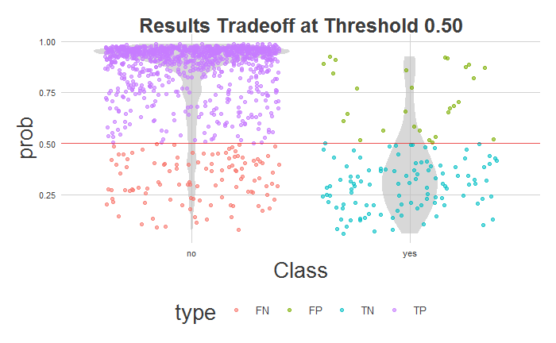

```r
plot_pred_type_distribution(df_test, threshold = 0.5)
```

```r
threshold_fn(model_name = model_ranger_both_smpl, cutoff__prob_yes = 0.3)
```

```
Confusion Matrix and Statistics

          Reference
Prediction  no yes
       no  906  14
       yes 194 121

               Accuracy : 0.8316
                 95% CI : (0.8095, 0.852)
    No Information Rate : 0.8907
    P-Value [Acc > NIR] : 1

                  Kappa : 0.4543

 Mcnemar's Test P-Value : <0.0000000000000002

            Sensitivity : 0.89630
            Specificity : 0.82364
         Pos Pred Value : 0.38413
         Neg Pred Value : 0.98478
             Prevalence : 0.10931
         Detection Rate : 0.09798
   Detection Prevalence : 0.25506
      Balanced Accuracy : 0.85997

       'Positive' Class : yes
```

```r
threshold_fn(model_name = model_ranger_both_smpl, cutoff__prob_yes = 0.25)
```

```
Confusion Matrix and Statistics

          Reference
Prediction  no yes
       no  872  13
       yes 228 122

               Accuracy : 0.8049
                 95% CI : (0.7816, 0.8266)
    No Information Rate : 0.8907
    P-Value [Acc > NIR] : 1

                  Kappa : 0.41

 Mcnemar's Test P-Value : <0.0000000000000002

            Sensitivity : 0.90370
            Specificity : 0.79273
         Pos Pred Value : 0.34857
         Neg Pred Value : 0.98531
             Prevalence : 0.10931
         Detection Rate : 0.09879
   Detection Prevalence : 0.28340
      Balanced Accuracy : 0.84822

       'Positive' Class : yes
```

**Above `ranger` method with changed threshold at `0.25` works even better than DT**.

```r
threshold_fn(model_name = model_ranger_both_smpl, cutoff__prob_yes = 0.2)
```

```
Confusion Matrix and Statistics

          Reference
Prediction  no yes
       no  828  11
       yes 272 124

               Accuracy : 0.7709
                 95% CI : (0.7464, 0.794)
    No Information Rate : 0.8907
    P-Value [Acc > NIR] : 1

                  Kappa : 0.3632

 Mcnemar's Test P-Value : <0.0000000000000002

            Sensitivity : 0.9185
            Specificity : 0.7527
         Pos Pred Value : 0.3131
         Neg Pred Value : 0.9869
             Prevalence : 0.1093
         Detection Rate : 0.1004
   Detection Prevalence : 0.3206
      Balanced Accuracy : 0.8356

       'Positive' Class : yes
```

```r
model_sensitivity_tbl <- confusionMatrix(reference = as.factor(pull(Y_test)) , data = ranger_pred_class_test, positive = "yes")[4] %>%
  list2DF()%>%
  head(n=1) %>%
  add_column(Model_type = "Ranger") %>%
  rbind(model_sensitivity_tbl)

model_sensitivity_tbl
```

| byClass | Model_type |
| --- | --- |
| 0.7925926 | Ranger |
| 0.7925926 | Ranger |
| 0.7333333 | RF |
| 0.9037037 | DT |
| 0.5185185 | knn |
| 0.7111111 | Adaboost |
| 0.8444444 | Mars5 |
| 0.8370370 | Mars1 |